# Avances LAPOP

José Rodríguez de la Fuente - Gonzalo Assusa

2022-09-16

# Preparación de la base

```r
#2008-2018
lapop2004_2018$democracia7 <- lapop2004_2018$ing4
lapop2004_2018$democracia_ord <- lapop2004_2018$pn4
lapop2004_2018$reduc_desigualdad <- lapop2004_2018$ros4

lapop2004_2018$country_f <- factor(lapop2004_2018$country,
                                   labels = c("México", "Colombia", "Perú",
                                              "Chile", "Uruguay", "Brasil", "Argentina"))

lapop2004_2018$sexo <- factor(lapop2004_2018$q1, labels = c("Varón", "Mujer"))

lapop2004_2018 <- lapop2004_2018 %>%
  mutate(categoria_ocup = case_when((colocup4a <= 2 | ocup4a <= 2) & ocup1a == 3 ~ 1,
                                  (colocup4a <= 2 | ocup4a <= 2) & ocup1a == 1 ~ 2,
                                  (colocup4a <= 2 | ocup4a <= 2) & ocup1a == 2 ~ 3,
                                  (colocup4a <= 2 | ocup4a <= 2) & ocup1a == 4 ~ 4,
                                  (colocup4a == 3 |ocup4a == 3) | ocup1a == 5 ~ 5,
                                  colocup4a >= 4 |ocup4a >= 4 ~ 6),
         categoria_ocup_f = factor(categoria_ocup, labels = c("Patrón", "Asalariado público",
                                                          "Asalariado privado",
                                                          "Cuenta propia", "Desocupado",
                                                          "Inactivo")),
         ing_decil = case_when(wave == 2008 | wave == 2010 ~ q10,
                               wave == 2012 ~ q10new_12,
                               wave == 2014 ~ q10new_14,
                               wave == 2016 ~ q10new_16,
                               wave == 2018 ~ q10new_18),
         ideologia = car::recode(l1, "1=10; 2=9; 3=8; 4=7; 5=6; 6=5; 7=4; 8=3; 9=2; 10=1"))

#2018
lapop2004_2018$desempleados <- lapop2004_2018$redist3
lapop2004_2018$desempleados <- car::recode(lapop2004_2018$desempleados,
                                           "7=1;6=2;5=3;4=4;3=5;2=6;1=7")

lapop2004_2018$ayuda_pobres <- lapop2004_2018$redist1

lapop2004_2018 <- lapop2004_2018 %>%
  mutate(redist2_inv = ifelse(wave == 2018, car::recode(redist2, "1=7; 2=6; 3=5; 4=4; 5=3;
                                                        6=2; 7=1"), NA),
         impuestos_ricos = ifelse(wave == 2018, case_when(country == 8 ~ redist2_inv,
                                     TRUE ~ redist2a), NA),
         urbano = ifelse(wave == 2018, factor(ur, labels = c("Urbano", "Rural")), NA),
         informal = ifelse(wave == 2018, car::recode(formal, "1=0; 2=1"), NA),
         formal_f = ifelse(wave == 2018, factor(formal, labels = c("formal", "informal")), NA),
         formal_estado = factor(ifelse(wave == 2018, case_when(formal == 1 ~ 1,
                                   formal == 2 ~ 2,
                                   categoria_ocup == 5 ~ 3,
                                   categoria_ocup == 6 ~ 4,
                                   TRUE ~ NA_real_), NA)),
         formal_estado = factor(formal_estado, labels = c("Formal", "Informal", "Desocupado",
                                                          "Inactivo")),
         formal_estado2 = factor(ifelse(wave == 2018, case_when(formal == 1 ~ 1,
                                   formal == 2 ~ 2,
                                   categoria_ocup >= 5 ~ 3,
                                   TRUE ~ NA_real_), NA)),
         formal_estado2 = factor(formal_estado2, labels = c("Formal", "Informal", "No ocupados")),
         estatus_ocup = ifelse(wave == 2018, case_when(ocupoit <= 2 ~ 1,
                                  ocupoit > 2 & ocupoit < 4 ~ 2,
                                  ocupoit %in% c(5, 7, 8, 10) ~ 3,
                                  ocupoit %in% c(6, 9) ~ 4,
                                  categoria_ocup >= 5 ~ 5,
                                  TRUE ~ NA_real_), NA),
         estatus_ocup_f = factor(estatus_ocup, labels =
                                                        c("Directivos-Profesionales",
                                                          "Técnicos-administrativos-vendedores",
                                                          "Trabajadores manuales calificados",
                                                          "Trabajadores manuales no calificados",
                                                          "No ocupados")))

#Pegado bases

lapop2004_2018 <- lapop2004_2018 %>%
  left_join(agregados, by = c("country_f", "wave"))

rm(paises_brecha, paises_desempleo, paises_empleopub, paises_informalidad)
```

# Casos perdidos variables objetivo

Data Frame Summary

lapop2004_2018

**Dimensions**: 66771 x 2  
**Duplicates**: 66707

| **No** | **Variable** | **Stats / Values** | **Freqs (% of Valid)** | **Graph** | **Missing** |
| --- | --- | --- | --- | --- | --- |
| 1 | democracia7 [numeric] | Mean (sd) : 5.2 (1.7) min ≤ med ≤ max: 1 ≤ 5 ≤ 7 IQR (CV) : 3 (0.3) | 1 : 2556 ( 4.0% ) 2 : 2328 ( 3.6% ) 3 : 5070 ( 7.9% ) 4 : 10045 ( 15.7% ) 5 : 12021 ( 18.8% ) 6 : 11202 ( 17.5% ) 7 : 20796 ( 32.5% ) |  | 2753 (4.1%) |
| 2 | reduc_desigualdad [numeric] | Mean (sd) : 5.7 (1.6) min ≤ med ≤ max: 1 ≤ 6 ≤ 7 IQR (CV) : 2 (0.3) | 1 : 1931 ( 3.0% ) 2 : 1659 ( 2.5% ) 3 : 2978 ( 4.6% ) 4 : 6419 ( 9.8% ) 5 : 9795 ( 15.0% ) 6 : 12511 ( 19.2% ) 7 : 29897 ( 45.9% ) |  | 1581 (2.4%) |

Generated by summarytools 1.0.1 ([R](https://www.r-project.org/) version 4.2.1)  
2022-09-16

Democracia 7 categorías x onda

|  | 2008 | 2010 | 2012 | 2014 | 2016 | 2018 | NA |
| --- | --- | --- | --- | --- | --- | --- | --- |
| 1 | 3.08 | 3.31 | 2.74 | 3.27 | 5.74 | 4.61 | NaN |
| 2 | 3.06 | 3.26 | 2.94 | 2.96 | 4.92 | 3.61 | NaN |
| 3 | 6.20 | 6.58 | 7.31 | 7.31 | 9.52 | 8.47 | NaN |
| 4 | 12.52 | 13.05 | 13.31 | 13.52 | 18.58 | 18.93 | NaN |
| 5 | 15.59 | 16.29 | 16.97 | 17.98 | 19.62 | 21.45 | NaN |
| 6 | 19.58 | 17.81 | 18.66 | 15.75 | 14.37 | 14.75 | NaN |
| 7 | 34.71 | 34.26 | 34.30 | 34.90 | 24.27 | 25.13 | NaN |
| NA | 5.25 | 5.43 | 3.77 | 4.28 | 2.98 | 3.05 | NaN |

Democracia 7 categorías x educación

|  | 0 | 1 | 2 | 3 | 4 | 5 | 6 | 7 | 8 | 9 | 10 | 11 | 12 | 13 | 14 | 15 | 16 | 17 | 18 | NA |
| --- | --- | --- | --- | --- | --- | --- | --- | --- | --- | --- | --- | --- | --- | --- | --- | --- | --- | --- | --- | --- |
| 1 | 5.14 | 6.81 | 4.44 | 4.20 | 3.72 | 4.81 | 3.92 | 4.27 | 4.39 | 4.47 | 3.96 | 4.03 | 3.20 | 3.11 | 2.85 | 2.67 | 2.62 | 2.26 | 2.94 | 10.34 |
| 2 | 4.64 | 5.40 | 5.00 | 4.35 | 4.00 | 4.50 | 3.07 | 3.91 | 3.73 | 3.47 | 2.98 | 4.23 | 2.70 | 3.38 | 3.02 | 2.18 | 2.45 | 2.17 | 2.88 | 7.13 |
| 3 | 7.30 | 8.10 | 8.39 | 8.07 | 8.40 | 8.28 | 7.44 | 7.59 | 7.72 | 8.23 | 7.27 | 9.47 | 6.79 | 7.15 | 6.94 | 4.64 | 6.78 | 4.11 | 5.28 | 10.57 |
| 4 | 12.69 | 11.97 | 12.82 | 13.38 | 12.53 | 14.77 | 14.32 | 13.00 | 15.79 | 17.25 | 14.10 | 18.23 | 15.30 | 14.70 | 15.93 | 11.87 | 13.12 | 10.99 | 13.18 | 17.93 |
| 5 | 15.26 | 15.73 | 15.32 | 17.15 | 18.03 | 17.86 | 16.36 | 17.01 | 19.46 | 20.10 | 16.63 | 20.35 | 18.45 | 19.01 | 18.65 | 15.41 | 15.95 | 14.41 | 15.38 | 19.08 |
| 6 | 12.11 | 13.38 | 16.85 | 16.67 | 18.39 | 17.24 | 17.05 | 16.10 | 16.92 | 15.27 | 15.43 | 16.74 | 17.38 | 17.06 | 18.82 | 16.72 | 18.93 | 18.94 | 14.25 | 11.49 |
| 7 | 26.78 | 25.00 | 25.24 | 26.71 | 26.84 | 24.53 | 31.73 | 33.08 | 27.34 | 27.60 | 36.15 | 24.63 | 33.32 | 33.72 | 32.69 | 45.52 | 39.19 | 46.33 | 45.22 | 14.94 |
| NA | 16.09 | 13.62 | 11.94 | 9.46 | 8.08 | 8.00 | 6.12 | 5.04 | 4.65 | 3.62 | 3.47 | 2.32 | 2.86 | 1.87 | 1.10 | 0.99 | 0.94 | 0.79 | 0.87 | 8.51 |

Democracia 7 categorías x ocupación

|  | Patrón | Asalariado público | Asalariado privado | Cuenta propia | Desocupado | Inactivo | NA |
| --- | --- | --- | --- | --- | --- | --- | --- |
| 1 | 4.40 | 2.71 | 3.26 | 4.22 | 4.95 | 3.82 | 5.33 |
| 2 | 3.60 | 2.81 | 2.85 | 3.92 | 4.09 | 3.59 | 3.13 |
| 3 | 7.45 | 6.35 | 6.75 | 8.15 | 9.10 | 7.61 | 9.72 |
| 4 | 13.37 | 12.84 | 14.84 | 15.84 | 18.21 | 14.52 | 15.52 |
| 5 | 15.37 | 16.41 | 17.58 | 18.45 | 20.37 | 17.89 | 18.81 |
| 6 | 16.41 | 17.15 | 17.48 | 16.57 | 15.12 | 16.92 | 12.07 |
| 7 | 37.47 | 40.01 | 34.63 | 28.87 | 24.39 | 30.11 | 26.02 |
| NA | 1.92 | 1.73 | 2.62 | 3.99 | 3.77 | 5.54 | 9.40 |

Democracia 7 categorías x ingresos (decil)

|  | 0 | 1 | 2 | 3 | 4 | 5 | 6 | 7 | 8 | 9 | 10 | 11 | 12 | 13 | 14 | 15 | 16 | NA |
| --- | --- | --- | --- | --- | --- | --- | --- | --- | --- | --- | --- | --- | --- | --- | --- | --- | --- | --- |
| 1 | 8.25 | 5.75 | 4.96 | 4.06 | 3.99 | 3.76 | 3.46 | 3.43 | 3.20 | 2.73 | 2.87 | 3.48 | 3.36 | 4.01 | 3.42 | 3.35 | 3.43 | 3.24 |
| 2 | 6.53 | 4.29 | 3.73 | 4.13 | 3.99 | 3.39 | 3.60 | 3.43 | 3.31 | 2.95 | 3.09 | 2.73 | 2.83 | 2.82 | 2.99 | 3.01 | 3.02 | 3.19 |
| 3 | 9.11 | 9.15 | 8.66 | 8.57 | 7.91 | 7.91 | 8.37 | 7.87 | 6.65 | 7.53 | 6.66 | 8.52 | 7.52 | 7.12 | 5.75 | 6.30 | 6.16 | 6.17 |
| 4 | 17.86 | 16.26 | 15.25 | 15.13 | 15.11 | 16.84 | 15.13 | 15.57 | 15.12 | 15.47 | 14.22 | 15.87 | 16.99 | 16.53 | 15.01 | 13.29 | 10.71 | 13.41 |
| 5 | 16.38 | 17.51 | 19.42 | 18.46 | 17.85 | 18.55 | 18.68 | 18.07 | 18.46 | 17.92 | 18.81 | 19.73 | 19.78 | 17.53 | 19.48 | 16.35 | 14.07 | 16.49 |
| 6 | 12.07 | 14.38 | 15.74 | 16.29 | 17.79 | 18.36 | 18.64 | 17.71 | 17.16 | 17.45 | 17.88 | 15.35 | 16.26 | 16.77 | 16.20 | 17.89 | 16.87 | 16.32 |
| 7 | 22.29 | 24.58 | 26.15 | 27.83 | 29.51 | 28.22 | 29.24 | 31.18 | 33.37 | 33.40 | 34.33 | 31.97 | 31.19 | 33.35 | 35.96 | 38.39 | 44.97 | 33.99 |
| NA | 7.51 | 8.07 | 6.08 | 5.52 | 3.85 | 2.98 | 2.88 | 2.74 | 2.74 | 2.54 | 2.14 | 2.35 | 2.06 | 1.86 | 1.19 | 1.42 | 0.77 | 7.19 |

Reducción de la desigualdad x onda

|  | 2008 | 2010 | 2012 | 2014 | 2016 | 2018 | NA |
| --- | --- | --- | --- | --- | --- | --- | --- |
| 1 | 2.01 | 1.64 | 1.58 | 2.98 | 4.39 | 4.63 | NaN |
| 2 | 1.74 | 1.76 | 1.41 | 2.92 | 3.64 | 3.35 | NaN |
| 3 | 3.16 | 3.19 | 2.98 | 4.72 | 5.74 | 6.88 | NaN |
| 4 | 7.01 | 7.16 | 8.54 | 9.88 | 11.54 | 13.46 | NaN |
| 5 | 12.40 | 12.96 | 14.83 | 14.89 | 15.68 | 17.23 | NaN |
| 6 | 20.15 | 20.02 | 20.50 | 17.25 | 17.71 | 16.85 | NaN |
| 7 | 49.80 | 50.26 | 47.97 | 44.63 | 39.78 | 36.50 | NaN |
| NA | 3.74 | 3.01 | 2.18 | 2.73 | 1.53 | 1.10 | NaN |

Reducción desigualdad x educación

|  | 0 | 1 | 2 | 3 | 4 | 5 | 6 | 7 | 8 | 9 | 10 | 11 | 12 | 13 | 14 | 15 | 16 | 17 | 18 | NA |
| --- | --- | --- | --- | --- | --- | --- | --- | --- | --- | --- | --- | --- | --- | --- | --- | --- | --- | --- | --- | --- |
| 1 | 5.31 | 5.16 | 4.03 | 3.73 | 3.27 | 3.16 | 3.12 | 3.36 | 2.84 | 3.10 | 2.58 | 2.53 | 2.24 | 2.27 | 2.46 | 2.38 | 2.42 | 2.36 | 4.15 | 8.28 |
| 2 | 2.57 | 3.52 | 3.71 | 3.20 | 2.82 | 2.89 | 2.62 | 2.04 | 2.31 | 2.56 | 2.69 | 2.46 | 1.83 | 2.27 | 2.26 | 2.47 | 2.51 | 1.62 | 2.88 | 7.59 |
| 3 | 4.56 | 5.05 | 5.08 | 4.49 | 4.50 | 4.43 | 4.17 | 4.02 | 4.28 | 4.34 | 3.63 | 5.02 | 3.92 | 4.58 | 4.58 | 4.35 | 5.19 | 4.11 | 5.35 | 5.52 |
| 4 | 7.30 | 6.34 | 7.34 | 9.99 | 8.58 | 8.86 | 8.41 | 9.16 | 7.72 | 9.74 | 8.54 | 10.59 | 9.89 | 9.37 | 11.52 | 9.65 | 10.29 | 10.25 | 13.44 | 14.94 |
| 5 | 13.10 | 12.68 | 12.98 | 12.04 | 11.90 | 13.47 | 13.40 | 13.87 | 13.90 | 14.78 | 13.75 | 16.51 | 16.04 | 15.37 | 16.30 | 14.13 | 15.07 | 13.58 | 14.38 | 14.25 |
| 6 | 14.59 | 16.78 | 18.79 | 18.06 | 17.21 | 18.83 | 17.21 | 17.38 | 18.52 | 17.48 | 17.85 | 20.19 | 19.00 | 20.97 | 20.88 | 19.80 | 20.85 | 18.66 | 17.06 | 12.87 |
| 7 | 42.04 | 42.14 | 41.53 | 42.90 | 46.50 | 45.04 | 48.18 | 47.06 | 48.17 | 46.16 | 48.63 | 41.33 | 45.36 | 44.47 | 41.45 | 46.01 | 42.94 | 48.50 | 41.54 | 30.34 |
| NA | 10.53 | 8.33 | 6.53 | 5.59 | 5.22 | 3.33 | 2.89 | 3.10 | 2.26 | 1.86 | 2.33 | 1.38 | 1.72 | 0.71 | 0.56 | 1.19 | 0.74 | 0.92 | 1.20 | 6.21 |

Reducción desigualdad x ocupación

|  | Patrón | Asalariado público | Asalariado privado | Cuenta propia | Desocupado | Inactivo | NA |
| --- | --- | --- | --- | --- | --- | --- | --- |
| 1 | 4.16 | 2.36 | 2.38 | 3.16 | 3.05 | 2.96 | 5.17 |
| 2 | 2.72 | 1.91 | 2.16 | 2.89 | 2.39 | 2.54 | 2.35 |
| 3 | 5.44 | 3.74 | 4.13 | 4.58 | 4.60 | 4.60 | 5.80 |
| 4 | 10.89 | 8.69 | 9.30 | 10.16 | 9.04 | 9.66 | 10.97 |
| 5 | 14.97 | 14.11 | 15.10 | 14.67 | 14.27 | 14.63 | 13.95 |
| 6 | 20.26 | 20.11 | 18.92 | 18.77 | 18.04 | 18.51 | 15.67 |
| 7 | 40.91 | 47.69 | 46.62 | 43.66 | 46.94 | 43.72 | 40.44 |
| NA | 0.64 | 1.40 | 1.40 | 2.12 | 1.67 | 3.38 | 5.64 |

Reducción desigualdad x ingresos (decil)

|  | 0 | 1 | 2 | 3 | 4 | 5 | 6 | 7 | 8 | 9 | 10 | 11 | 12 | 13 | 14 | 15 | 16 | NA |
| --- | --- | --- | --- | --- | --- | --- | --- | --- | --- | --- | --- | --- | --- | --- | --- | --- | --- | --- |
| 1 | 4.56 | 3.98 | 2.43 | 3.09 | 2.54 | 2.63 | 2.45 | 2.19 | 2.33 | 2.01 | 3.22 | 2.45 | 2.47 | 2.91 | 2.66 | 3.29 | 4.56 | 3.34 |
| 2 | 4.80 | 3.31 | 2.64 | 2.15 | 2.19 | 2.59 | 2.26 | 2.36 | 2.36 | 2.64 | 2.26 | 2.97 | 2.35 | 2.48 | 2.52 | 2.44 | 2.92 | 2.10 |
| 3 | 5.91 | 4.16 | 4.19 | 3.89 | 4.07 | 4.19 | 4.12 | 4.25 | 4.64 | 4.49 | 5.39 | 3.86 | 4.98 | 4.25 | 4.89 | 4.32 | 5.36 | 4.97 |
| 4 | 11.45 | 8.88 | 8.01 | 8.31 | 8.74 | 9.19 | 9.41 | 8.99 | 10.42 | 10.45 | 9.60 | 10.69 | 11.17 | 9.89 | 10.40 | 11.98 | 11.59 | 10.26 |
| 5 | 12.44 | 12.17 | 13.40 | 14.35 | 14.06 | 14.79 | 15.92 | 14.40 | 14.60 | 15.13 | 14.50 | 15.11 | 16.18 | 17.20 | 17.10 | 16.41 | 15.60 | 14.64 |
| 6 | 14.78 | 16.10 | 18.85 | 18.91 | 19.17 | 20.75 | 19.64 | 20.48 | 19.61 | 20.09 | 20.62 | 18.27 | 19.78 | 19.35 | 18.76 | 17.49 | 17.42 | 16.54 |
| 7 | 41.75 | 47.17 | 47.05 | 46.73 | 47.19 | 44.10 | 44.54 | 45.32 | 44.34 | 44.22 | 43.29 | 45.53 | 42.03 | 42.76 | 42.61 | 43.50 | 41.95 | 43.30 |
| NA | 4.31 | 4.23 | 3.42 | 2.57 | 2.04 | 1.76 | 1.64 | 2.00 | 1.70 | 0.97 | 1.12 | 1.13 | 1.05 | 1.15 | 1.05 | 0.57 | 0.62 | 4.85 |

Data Frame Summary

lapop2018

**Dimensions**: 11009 x 3  
**Duplicates**: 10569

| **No** | **Variable** | **Stats / Values** | **Freqs (% of Valid)** | **Graph** | **Missing** |
| --- | --- | --- | --- | --- | --- |
| 1 | desempleados [numeric] | Mean (sd) : 3.4 (2) min ≤ med ≤ max: 1 ≤ 3 ≤ 7 IQR (CV) : 3 (0.6) | 1 : 2549 ( 23.3% ) 2 : 1612 ( 14.7% ) 3 : 1897 ( 17.3% ) 4 : 1579 ( 14.4% ) 5 : 1167 ( 10.7% ) 6 : 908 ( 8.3% ) 7 : 1222 ( 11.2% ) |  | 75 (0.7%) |
| 2 | impuestos_ricos [numeric] | Mean (sd) : 4.3 (1.9) min ≤ med ≤ max: 1 ≤ 4 ≤ 7 IQR (CV) : 3 (0.4) | 1 : 1268 ( 11.8% ) 2 : 861 ( 8.0% ) 3 : 1306 ( 12.2% ) 4 : 2252 ( 21.0% ) 5 : 1962 ( 18.3% ) 6 : 1253 ( 11.7% ) 7 : 1838 ( 17.1% ) |  | 269 (2.4%) |
| 3 | ayuda_pobres [numeric] | Mean (sd) : 5.5 (1.8) min ≤ med ≤ max: 1 ≤ 6 ≤ 7 IQR (CV) : 3 (0.3) | 1 : 505 ( 4.6% ) 2 : 379 ( 3.5% ) 3 : 640 ( 5.8% ) 4 : 1294 ( 11.8% ) 5 : 1501 ( 13.7% ) 6 : 1734 ( 15.8% ) 7 : 4893 ( 44.7% ) |  | 63 (0.6%) |

Generated by summarytools 1.0.1 ([R](https://www.r-project.org/) version 4.2.1)  
2022-09-16

Desempleados x educación

|  | 0 | 1 | 2 | 3 | 4 | 5 | 6 | 7 | 8 | 9 | 10 | 11 | 12 | 13 | 14 | 15 | 16 | 17 | 18 | NA |
| --- | --- | --- | --- | --- | --- | --- | --- | --- | --- | --- | --- | --- | --- | --- | --- | --- | --- | --- | --- | --- |
| 1 | 26.92 | 29.41 | 21.48 | 26.55 | 28.33 | 27.59 | 25.54 | 26.10 | 28.64 | 28.10 | 23.86 | 21.17 | 24.90 | 18.55 | 18.33 | 17.15 | 15.38 | 18.82 | 17.16 | 19.78 |
| 2 | 15.38 | 13.73 | 17.45 | 18.18 | 14.68 | 17.00 | 17.63 | 14.09 | 15.08 | 16.94 | 14.39 | 13.96 | 13.03 | 12.53 | 15.68 | 12.47 | 14.17 | 12.47 | 12.19 | 19.78 |
| 3 | 13.85 | 12.75 | 18.12 | 14.91 | 13.99 | 18.47 | 19.42 | 15.24 | 15.93 | 19.42 | 14.96 | 18.42 | 18.26 | 18.55 | 20.77 | 14.70 | 16.60 | 12.02 | 14.00 | 14.29 |
| 4 | 10.77 | 9.80 | 10.07 | 12.36 | 11.95 | 9.61 | 11.39 | 12.24 | 12.37 | 11.98 | 16.10 | 14.95 | 16.06 | 15.66 | 17.72 | 16.93 | 15.38 | 16.55 | 18.06 | 17.58 |
| 5 | 8.46 | 8.82 | 10.74 | 10.55 | 10.92 | 10.59 | 7.55 | 9.70 | 9.15 | 7.85 | 8.90 | 11.21 | 10.58 | 11.57 | 11.81 | 15.14 | 14.17 | 14.29 | 11.29 | 8.79 |
| 6 | 6.15 | 6.86 | 8.05 | 6.55 | 6.83 | 5.91 | 6.83 | 8.55 | 6.10 | 7.23 | 8.90 | 7.73 | 7.74 | 8.19 | 7.94 | 8.69 | 11.74 | 14.51 | 13.54 | 9.89 |
| 7 | 15.38 | 16.67 | 10.74 | 8.73 | 11.95 | 9.85 | 11.03 | 13.63 | 12.37 | 7.54 | 11.93 | 12.04 | 8.90 | 14.70 | 7.54 | 14.92 | 11.94 | 11.11 | 13.32 | 8.79 |
| NA | 3.08 | 1.96 | 3.36 | 2.18 | 1.37 | 0.99 | 0.60 | 0.46 | 0.34 | 0.93 | 0.95 | 0.52 | 0.52 | 0.24 | 0.20 | 0.00 | 0.61 | 0.23 | 0.45 | 1.10 |

Desempleados x ocupación

|  | Patrón | Asalariado público | Asalariado privado | Cuenta propia | Desocupado | Inactivo | NA |
| --- | --- | --- | --- | --- | --- | --- | --- |
| 1 | 28.08 | 22.09 | 23.30 | 24.52 | 22.16 | 22.42 | 25.93 |
| 2 | 16.54 | 12.29 | 14.57 | 14.83 | 13.23 | 15.15 | 19.26 |
| 3 | 16.15 | 15.95 | 17.88 | 18.43 | 14.85 | 17.32 | 14.81 |
| 4 | 15.38 | 15.95 | 15.48 | 14.06 | 13.15 | 13.96 | 13.33 |
| 5 | 10.77 | 11.24 | 10.83 | 9.34 | 9.33 | 11.46 | 9.63 |
| 6 | 5.77 | 11.24 | 8.01 | 7.72 | 8.12 | 8.29 | 8.89 |
| 7 | 7.31 | 11.11 | 9.78 | 10.37 | 18.34 | 10.41 | 6.67 |
| NA | 0.00 | 0.13 | 0.14 | 0.73 | 0.81 | 1.00 | 1.48 |

Desempleados x ingresos (decil)

|  | 0 | 1 | 2 | 3 | 4 | 5 | 6 | 7 | 8 | 9 | 10 | 11 | 12 | 13 | 14 | 15 | 16 | NA |
| --- | --- | --- | --- | --- | --- | --- | --- | --- | --- | --- | --- | --- | --- | --- | --- | --- | --- | --- |
| 1 | 27.35 | 27.35 | 25.75 | 25.76 | 26.87 | 20.29 | 23.71 | 19.06 | 21.72 | 24.47 | 24.80 | 21.12 | 22.51 | 19.59 | 20.62 | 22.84 | 20.24 | 22.76 |
| 2 | 12.56 | 15.15 | 15.45 | 13.96 | 13.67 | 14.17 | 17.26 | 13.81 | 13.10 | 16.18 | 15.76 | 14.15 | 15.01 | 13.86 | 16.32 | 13.53 | 13.38 | 14.53 |
| 3 | 13.45 | 16.18 | 17.34 | 15.40 | 14.94 | 19.48 | 17.58 | 19.41 | 18.74 | 17.53 | 16.38 | 19.57 | 19.70 | 19.96 | 16.49 | 15.96 | 15.09 | 16.45 |
| 4 | 8.52 | 11.91 | 12.06 | 12.81 | 11.13 | 15.94 | 13.23 | 18.36 | 16.75 | 16.96 | 17.16 | 15.31 | 14.26 | 14.97 | 13.23 | 15.08 | 15.95 | 13.70 |
| 5 | 10.31 | 8.82 | 9.67 | 10.50 | 10.17 | 11.43 | 10.32 | 10.14 | 10.28 | 8.48 | 9.83 | 11.43 | 14.07 | 13.68 | 10.48 | 9.09 | 13.21 | 10.05 |
| 6 | 9.42 | 7.65 | 7.54 | 8.06 | 6.36 | 8.53 | 6.94 | 9.27 | 7.46 | 7.32 | 6.55 | 8.91 | 6.57 | 8.32 | 11.17 | 10.64 | 10.46 | 8.72 |
| 7 | 15.25 | 11.91 | 11.81 | 12.95 | 15.90 | 8.70 | 10.48 | 9.79 | 11.61 | 9.06 | 9.20 | 8.72 | 7.69 | 9.43 | 11.34 | 11.97 | 11.49 | 12.29 |
| NA | 3.14 | 1.03 | 0.38 | 0.58 | 0.95 | 1.45 | 0.48 | 0.17 | 0.33 | 0.00 | 0.31 | 0.78 | 0.19 | 0.18 | 0.34 | 0.89 | 0.17 | 1.50 |

Ayuda pobres x educación

|  | 0 | 1 | 2 | 3 | 4 | 5 | 6 | 7 | 8 | 9 | 10 | 11 | 12 | 13 | 14 | 15 | 16 | 17 | 18 | NA |
| --- | --- | --- | --- | --- | --- | --- | --- | --- | --- | --- | --- | --- | --- | --- | --- | --- | --- | --- | --- | --- |
| 1 | 11.54 | 5.88 | 5.37 | 3.64 | 3.75 | 3.20 | 5.04 | 3.93 | 4.24 | 4.55 | 7.58 | 2.65 | 4.26 | 3.13 | 3.87 | 6.01 | 5.47 | 7.71 | 7.67 | 3.30 |
| 2 | 2.31 | 5.88 | 1.34 | 0.73 | 1.71 | 1.48 | 3.84 | 2.08 | 2.88 | 2.79 | 3.98 | 2.54 | 3.68 | 3.13 | 4.07 | 6.90 | 6.28 | 5.44 | 4.51 | 4.40 |
| 3 | 3.08 | 7.84 | 3.36 | 5.09 | 2.73 | 2.22 | 3.60 | 5.31 | 4.07 | 4.55 | 5.68 | 4.26 | 6.52 | 8.67 | 8.15 | 9.80 | 7.49 | 9.98 | 12.19 | 3.30 |
| 4 | 9.23 | 6.86 | 8.72 | 8.00 | 4.10 | 3.69 | 7.91 | 6.24 | 6.95 | 9.50 | 13.64 | 8.72 | 16.00 | 16.39 | 16.50 | 18.04 | 16.80 | 20.18 | 20.09 | 8.79 |
| 5 | 9.23 | 3.92 | 8.05 | 9.82 | 9.90 | 10.84 | 11.87 | 11.55 | 11.02 | 11.16 | 10.23 | 14.17 | 14.52 | 15.90 | 14.66 | 18.04 | 19.64 | 20.18 | 17.83 | 16.48 |
| 6 | 13.08 | 9.80 | 15.44 | 13.82 | 15.70 | 14.78 | 17.51 | 15.47 | 14.41 | 16.63 | 13.26 | 16.81 | 15.29 | 16.63 | 18.74 | 13.81 | 18.02 | 12.47 | 15.58 | 15.38 |
| 7 | 50.00 | 58.82 | 57.05 | 57.82 | 61.43 | 63.55 | 48.80 | 55.20 | 56.10 | 50.41 | 45.27 | 50.34 | 39.29 | 35.90 | 33.81 | 26.50 | 25.71 | 23.13 | 21.90 | 47.25 |
| NA | 1.54 | 0.98 | 0.67 | 1.09 | 0.68 | 0.25 | 1.44 | 0.23 | 0.34 | 0.41 | 0.38 | 0.52 | 0.45 | 0.24 | 0.20 | 0.89 | 0.61 | 0.91 | 0.23 | 1.10 |

Ayuda pobres x ocupación

|  | Patrón | Asalariado público | Asalariado privado | Cuenta propia | Desocupado | Inactivo | NA |
| --- | --- | --- | --- | --- | --- | --- | --- |
| 1 | 4.62 | 5.36 | 5.80 | 4.59 | 3.81 | 4.05 | 5.19 |
| 2 | 3.85 | 5.49 | 3.98 | 3.34 | 3.08 | 2.98 | 2.22 |
| 3 | 7.69 | 7.32 | 7.09 | 5.49 | 4.22 | 5.48 | 4.44 |
| 4 | 11.92 | 14.77 | 14.09 | 10.93 | 10.15 | 11.01 | 10.37 |
| 5 | 16.92 | 17.12 | 14.09 | 13.80 | 11.85 | 12.96 | 14.81 |
| 6 | 15.38 | 13.99 | 14.81 | 15.65 | 14.69 | 17.03 | 12.59 |
| 7 | 39.23 | 35.42 | 39.98 | 45.48 | 51.87 | 45.76 | 48.15 |
| NA | 0.38 | 0.52 | 0.14 | 0.73 | 0.32 | 0.74 | 2.22 |

Ayuda pobres x ingresos (decil)

|  | 0 | 1 | 2 | 3 | 4 | 5 | 6 | 7 | 8 | 9 | 10 | 11 | 12 | 13 | 14 | 15 | 16 | NA |
| --- | --- | --- | --- | --- | --- | --- | --- | --- | --- | --- | --- | --- | --- | --- | --- | --- | --- | --- |
| 1 | 7.17 | 2.94 | 3.52 | 3.17 | 4.77 | 4.35 | 3.55 | 4.55 | 4.31 | 4.24 | 5.15 | 4.84 | 3.94 | 4.81 | 6.70 | 5.54 | 6.00 | 5.15 |
| 2 | 2.24 | 2.35 | 2.51 | 2.30 | 1.91 | 2.74 | 2.42 | 3.50 | 3.98 | 3.66 | 3.28 | 3.49 | 3.19 | 4.81 | 3.61 | 5.99 | 6.69 | 3.82 |
| 3 | 2.69 | 3.68 | 2.89 | 6.33 | 4.29 | 4.51 | 4.52 | 5.77 | 5.14 | 6.17 | 6.55 | 5.43 | 7.69 | 7.58 | 7.90 | 8.65 | 9.61 | 5.81 |
| 4 | 6.73 | 6.18 | 8.17 | 8.92 | 8.11 | 10.47 | 12.26 | 11.71 | 11.28 | 14.07 | 11.86 | 13.37 | 14.26 | 14.05 | 14.26 | 19.96 | 17.50 | 11.46 |
| 5 | 8.52 | 7.94 | 10.93 | 10.07 | 13.83 | 14.17 | 14.84 | 12.59 | 10.78 | 14.07 | 15.44 | 16.28 | 16.70 | 16.64 | 16.15 | 14.19 | 19.55 | 13.29 |
| 6 | 12.11 | 15.59 | 16.71 | 17.70 | 15.26 | 16.43 | 17.58 | 14.86 | 15.75 | 17.53 | 14.98 | 16.09 | 17.45 | 15.90 | 15.98 | 17.29 | 11.15 | 14.37 |
| 7 | 60.09 | 60.44 | 54.90 | 50.94 | 51.35 | 46.22 | 44.19 | 46.50 | 47.76 | 40.27 | 42.75 | 40.50 | 36.40 | 35.86 | 35.40 | 27.94 | 28.64 | 44.85 |
| NA | 0.45 | 0.88 | 0.38 | 0.58 | 0.48 | 1.13 | 0.65 | 0.52 | 1.00 | 0.00 | 0.00 | 0.00 | 0.38 | 0.37 | 0.00 | 0.44 | 0.86 | 1.25 |

Impuestos ricos x educación

|  | 0 | 1 | 2 | 3 | 4 | 5 | 6 | 7 | 8 | 9 | 10 | 11 | 12 | 13 | 14 | 15 | 16 | 17 | 18 | NA |
| --- | --- | --- | --- | --- | --- | --- | --- | --- | --- | --- | --- | --- | --- | --- | --- | --- | --- | --- | --- | --- |
| 1 | 16.15 | 17.65 | 12.75 | 13.09 | 13.99 | 14.78 | 10.55 | 13.16 | 12.20 | 11.57 | 12.69 | 13.03 | 9.03 | 9.16 | 8.35 | 10.47 | 9.92 | 11.11 | 11.74 | 10.99 |
| 2 | 11.54 | 5.88 | 8.05 | 8.36 | 8.53 | 9.36 | 7.31 | 6.00 | 7.63 | 6.10 | 8.71 | 10.07 | 5.55 | 5.30 | 7.94 | 6.90 | 9.72 | 7.48 | 9.93 | 8.79 |
| 3 | 5.38 | 11.76 | 14.09 | 13.45 | 10.58 | 12.56 | 10.79 | 9.93 | 9.15 | 9.92 | 13.45 | 14.32 | 10.00 | 12.05 | 13.65 | 11.80 | 10.73 | 12.24 | 16.03 | 15.38 |
| 4 | 15.38 | 11.76 | 17.45 | 18.91 | 14.68 | 15.52 | 15.35 | 18.01 | 19.15 | 20.87 | 19.70 | 19.93 | 23.68 | 23.37 | 24.64 | 22.72 | 25.71 | 19.95 | 24.83 | 16.48 |
| 5 | 16.92 | 9.80 | 13.42 | 11.27 | 15.02 | 14.53 | 20.02 | 17.32 | 15.93 | 18.90 | 16.48 | 16.71 | 20.71 | 23.13 | 17.31 | 18.04 | 17.61 | 21.54 | 14.90 | 18.68 |
| 6 | 9.23 | 9.80 | 10.74 | 12.00 | 10.58 | 11.82 | 12.83 | 12.93 | 13.90 | 12.09 | 8.71 | 10.33 | 12.71 | 11.08 | 13.85 | 9.80 | 9.11 | 10.88 | 9.48 | 6.59 |
| 7 | 20.00 | 24.51 | 18.12 | 18.55 | 20.14 | 18.23 | 19.30 | 21.02 | 20.17 | 18.18 | 17.42 | 14.06 | 15.81 | 13.73 | 13.44 | 18.93 | 15.18 | 15.19 | 11.96 | 19.78 |
| NA | 5.38 | 8.82 | 5.37 | 4.36 | 6.48 | 3.20 | 3.84 | 1.62 | 1.86 | 2.38 | 2.84 | 1.56 | 2.52 | 2.17 | 0.81 | 1.34 | 2.02 | 1.59 | 1.13 | 3.30 |

Impuestos ricos x ocupación

|  | Patrón | Asalariado público | Asalariado privado | Cuenta propia | Desocupado | Inactivo | NA |
| --- | --- | --- | --- | --- | --- | --- | --- |
| 1 | 9.23 | 11.24 | 10.64 | 12.39 | 13.31 | 11.05 | 14.07 |
| 2 | 8.85 | 6.80 | 6.71 | 8.02 | 8.04 | 8.34 | 7.41 |
| 3 | 13.46 | 11.50 | 11.98 | 11.40 | 11.69 | 12.17 | 8.89 |
| 4 | 23.46 | 21.96 | 21.52 | 21.30 | 19.89 | 19.34 | 14.81 |
| 5 | 20.00 | 18.30 | 19.32 | 16.89 | 17.37 | 17.53 | 17.04 |
| 6 | 7.31 | 11.63 | 11.89 | 10.89 | 9.82 | 12.01 | 13.33 |
| 7 | 17.31 | 16.99 | 16.78 | 17.36 | 17.53 | 15.84 | 20.00 |
| NA | 0.38 | 1.57 | 1.15 | 1.76 | 2.35 | 3.72 | 4.44 |

Impuestos ricos x ingresos (decil)

|  | 0 | 1 | 2 | 3 | 4 | 5 | 6 | 7 | 8 | 9 | 10 | 11 | 12 | 13 | 14 | 15 | 16 | NA |
| --- | --- | --- | --- | --- | --- | --- | --- | --- | --- | --- | --- | --- | --- | --- | --- | --- | --- | --- |
| 1 | 17.49 | 15.44 | 11.56 | 11.08 | 13.67 | 9.98 | 10.00 | 9.27 | 8.96 | 11.75 | 11.70 | 8.91 | 7.88 | 11.09 | 13.92 | 12.42 | 13.21 | 11.63 |
| 2 | 13.45 | 8.24 | 7.29 | 9.35 | 9.06 | 7.41 | 6.45 | 5.94 | 6.80 | 5.59 | 8.11 | 9.11 | 6.57 | 7.02 | 9.79 | 8.87 | 9.61 | 6.64 |
| 3 | 8.52 | 11.62 | 12.81 | 11.22 | 11.61 | 11.59 | 11.13 | 12.06 | 10.28 | 11.95 | 11.08 | 10.47 | 12.76 | 13.49 | 11.51 | 14.19 | 14.41 | 11.63 |
| 4 | 15.70 | 15.00 | 18.47 | 20.00 | 17.17 | 18.36 | 21.94 | 24.30 | 21.56 | 22.35 | 21.68 | 25.97 | 20.83 | 22.00 | 20.79 | 24.83 | 23.50 | 17.69 |
| 5 | 8.52 | 15.74 | 16.33 | 16.26 | 14.94 | 21.58 | 17.74 | 20.10 | 21.23 | 19.65 | 17.63 | 18.02 | 22.33 | 19.04 | 17.35 | 17.52 | 17.50 | 16.61 |
| 6 | 14.35 | 10.29 | 11.31 | 11.37 | 12.08 | 13.20 | 13.23 | 10.84 | 12.77 | 11.37 | 11.70 | 10.47 | 13.32 | 10.91 | 12.03 | 7.32 | 9.09 | 10.71 |
| 7 | 17.94 | 20.15 | 19.72 | 17.55 | 19.24 | 15.94 | 17.26 | 16.43 | 15.75 | 15.99 | 17.32 | 15.70 | 14.45 | 14.60 | 13.06 | 13.30 | 11.49 | 19.27 |
| NA | 4.04 | 3.53 | 2.51 | 3.17 | 2.23 | 1.93 | 2.26 | 1.05 | 2.65 | 1.35 | 0.78 | 1.36 | 1.88 | 1.85 | 1.55 | 1.55 | 1.20 | 5.81 |

Se observa que para las variables objetivo de *impuestos*, *ayuda a la pobreza* y *desempleo* no existiría un sesgo importante por parte de los grupos más desfavorecidos en educación, ingresos y trabajo. Por tal motivo, esos casos perdidos pueden ser no considerados en el análisis.

Se realiza un análisis de correspondencias múltiples para observar el vínculo entre la variable de *democracia* y *reducción de la desigualdad*. De este surge que los grupos más desfavorecidos son los que menos reponden a dichas preguntas.

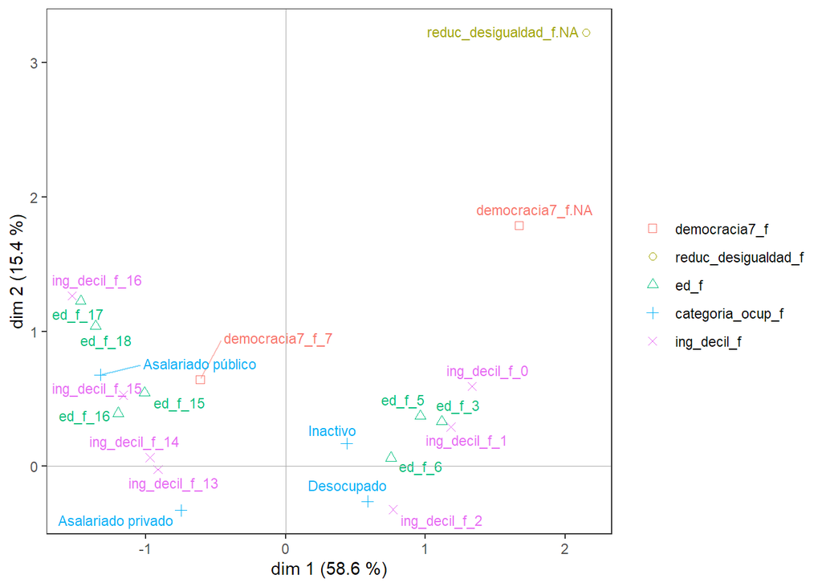

## Imputación variables objetivo

```r
#1) Random Hot Deck para la variable democracia7 -----

lapop2004_2018$democracia7_imp <- lapop2004_2018$democracia7

set.seed(971986)
lapop2004_2018 <- lapop2004_2018 %>%
  hotdeck(variable = "democracia7_imp",
          domain_var = "ing_decil",
          imp_suffix = "check")

print(lapop2004_2018 %>%
  select(democracia7, democracia7_imp) %>%
  summarytools::dfSummary(plain.ascii  = FALSE,
          style        = "grid",
          graph.magnif = 0.75,
          valid.col    = FALSE),
  method = "render")
```

Data Frame Summary

lapop2004_2018

**Dimensions**: 66771 x 2  
**Duplicates**: 66757

| **No** | **Variable** | **Stats / Values** | **Freqs (% of Valid)** | **Graph** | **Missing** |
| --- | --- | --- | --- | --- | --- |
| 1 | democracia7 [numeric] | Mean (sd) : 5.2 (1.7) min ≤ med ≤ max: 1 ≤ 5 ≤ 7 IQR (CV) : 3 (0.3) | 1 : 2556 ( 4.0% ) 2 : 2328 ( 3.6% ) 3 : 5070 ( 7.9% ) 4 : 10045 ( 15.7% ) 5 : 12021 ( 18.8% ) 6 : 11202 ( 17.5% ) 7 : 20796 ( 32.5% ) |  | 2753 (4.1%) |
| 2 | democracia7_imp [numeric] | Mean (sd) : 5.2 (1.7) min ≤ med ≤ max: 1 ≤ 5 ≤ 7 IQR (CV) : 3 (0.3) | 1 : 2677 ( 4.0% ) 2 : 2427 ( 3.6% ) 3 : 5305 ( 7.9% ) 4 : 10497 ( 15.7% ) 5 : 12569 ( 18.8% ) 6 : 11666 ( 17.5% ) 7 : 21630 ( 32.4% ) |  | 0 (0.0%) |

Generated by summarytools 1.0.1 ([R](https://www.r-project.org/) version 4.2.1)  
2022-09-16

```r
#2) Random Hot Deck para la variable reduc_desigualdad -----
lapop2004_2018$reduc_desigualdad_imp <- lapop2004_2018$reduc_desigualdad

set.seed(971986)
lapop2004_2018 <- lapop2004_2018 %>%
  hotdeck(variable = "reduc_desigualdad_imp",
          domain_var = "ing_decil",
          imp_suffix = "check")

print(lapop2004_2018 %>%
  select(reduc_desigualdad, reduc_desigualdad_imp) %>%
  summarytools::dfSummary(plain.ascii  = FALSE,
          style        = "grid",
          graph.magnif = 0.75,
          valid.col    = FALSE),
  method = "render")
```

Data Frame Summary

lapop2004_2018

**Dimensions**: 66771 x 2  
**Duplicates**: 66757

| **No** | **Variable** | **Stats / Values** | **Freqs (% of Valid)** | **Graph** | **Missing** |
| --- | --- | --- | --- | --- | --- |
| 1 | reduc_desigualdad [numeric] | Mean (sd) : 5.7 (1.6) min ≤ med ≤ max: 1 ≤ 6 ≤ 7 IQR (CV) : 2 (0.3) | 1 : 1931 ( 3.0% ) 2 : 1659 ( 2.5% ) 3 : 2978 ( 4.6% ) 4 : 6419 ( 9.8% ) 5 : 9795 ( 15.0% ) 6 : 12511 ( 19.2% ) 7 : 29897 ( 45.9% ) |  | 1581 (2.4%) |
| 2 | reduc_desigualdad_imp [numeric] | Mean (sd) : 5.7 (1.6) min ≤ med ≤ max: 1 ≤ 6 ≤ 7 IQR (CV) : 2 (0.3) | 1 : 1975 ( 3.0% ) 2 : 1698 ( 2.5% ) 3 : 3048 ( 4.6% ) 4 : 6553 ( 9.8% ) 5 : 10030 ( 15.0% ) 6 : 12816 ( 19.2% ) 7 : 30651 ( 45.9% ) |  | 0 (0.0%) |

Generated by summarytools 1.0.1 ([R](https://www.r-project.org/) version 4.2.1)  
2022-09-16

# Casos perdidos variables predictoras

```r
print(lapop2004_2018 %>%
  select(ideologia) %>%
  summarytools::dfSummary(plain.ascii  = FALSE,
          style        = "grid",
          graph.magnif = 0.75,
          valid.col    = FALSE),
  method = "render")
```

Data Frame Summary

lapop2004_2018

**Dimensions**: 66771 x 1  
**Duplicates**: 66760

**Variable**

**Stats / Values**

**Freqs (% of Valid)**

**Graph**

**Missing**

1

ideologia [numeric]

| Mean (sd) : 5.5 (2.5) |
| --- |
| min ≤ med ≤ max: |
| 1 ≤ 6 ≤ 10 |
| IQR (CV) : 3 (0.4) |

| 1 | : | 4863 | ( | 8.6% | ) |
| --- | --- | --- | --- | --- | --- |
| 2 | : | 2363 | ( | 4.2% | ) |
| 3 | : | 5310 | ( | 9.3% | ) |
| 4 | : | 4844 | ( | 8.5% | ) |
| 5 | : | 7295 | ( | 12.8% | ) |
| 6 | : | 14855 | ( | 26.1% | ) |
| 7 | : | 5318 | ( | 9.4% | ) |
| 8 | : | 4989 | ( | 8.8% | ) |
| 9 | : | 2380 | ( | 4.2% | ) |
| 10 | : | 4594 | ( | 8.1% | ) |

9960 (14.9%)

Generated by summarytools 1.0.1 ([R](https://www.r-project.org/) version 4.2.1)  
2022-09-16

```r
kable(round(prop.table(table(lapop2004_2018$ideologia, lapop2004_2018$wave,
                 useNA = "always"), margin = 2)*100, digits = 2),
      format = "html", caption = "Ideología x onda") %>%
  kable_styling()
```

Ideología x onda

|  | 2008 | 2010 | 2012 | 2014 | 2016 | 2018 | NA |
| --- | --- | --- | --- | --- | --- | --- | --- |
| 1 | 6.25 | 5.88 | 7.18 | 7.23 | 7.82 | 9.37 | NaN |
| 2 | 3.99 | 3.50 | 3.50 | 3.60 | 3.26 | 3.43 | NaN |
| 3 | 8.71 | 8.13 | 7.68 | 7.40 | 7.54 | 8.28 | NaN |
| 4 | 8.18 | 8.02 | 6.96 | 6.32 | 6.56 | 7.48 | NaN |
| 5 | 14.95 | 12.26 | 11.60 | 8.84 | 9.10 | 8.97 | NaN |
| 6 | 20.57 | 20.28 | 22.14 | 22.05 | 24.05 | 24.33 | NaN |
| 7 | 7.60 | 7.79 | 7.52 | 7.55 | 8.85 | 8.37 | NaN |
| 8 | 6.93 | 6.80 | 6.68 | 7.33 | 8.77 | 8.20 | NaN |
| 9 | 2.93 | 3.31 | 3.12 | 3.16 | 4.59 | 4.15 | NaN |
| 10 | 4.55 | 5.24 | 6.26 | 6.93 | 9.33 | 8.78 | NaN |
| NA | 15.32 | 18.79 | 17.36 | 19.59 | 10.14 | 8.64 | NaN |

```r
kable(round(prop.table(table(lapop2004_2018$ideologia, lapop2004_2018$ing_decil,
                 useNA = "always"), margin = 2)*100, digits = 2),
      format = "html", caption = "Ideología x ingreso") %>%
  kable_styling()
```

Ideología x ingreso

|  | 0 | 1 | 2 | 3 | 4 | 5 | 6 | 7 | 8 | 9 | 10 | 11 | 12 | 13 | 14 | 15 | 16 | NA |
| --- | --- | --- | --- | --- | --- | --- | --- | --- | --- | --- | --- | --- | --- | --- | --- | --- | --- | --- |
| 1 | 9.98 | 9.93 | 7.67 | 7.70 | 7.82 | 6.80 | 6.79 | 6.88 | 7.34 | 6.43 | 6.63 | 7.77 | 6.03 | 6.35 | 5.99 | 7.38 | 7.51 | 6.64 |
| 2 | 4.80 | 4.09 | 3.54 | 4.10 | 3.61 | 3.87 | 3.67 | 3.78 | 3.51 | 3.74 | 3.38 | 3.44 | 3.80 | 2.58 | 2.66 | 3.07 | 2.99 | 3.04 |
| 3 | 7.51 | 7.78 | 8.11 | 7.79 | 7.65 | 8.19 | 8.22 | 8.53 | 7.95 | 7.88 | 8.19 | 8.29 | 7.73 | 8.31 | 8.79 | 8.63 | 8.75 | 7.00 |
| 4 | 4.68 | 6.46 | 6.93 | 7.17 | 7.87 | 7.89 | 7.05 | 7.27 | 7.66 | 7.63 | 6.95 | 6.17 | 7.12 | 8.22 | 7.46 | 8.35 | 8.16 | 6.88 |
| 5 | 7.64 | 9.77 | 11.05 | 11.31 | 11.59 | 12.12 | 11.92 | 11.68 | 11.69 | 9.98 | 11.28 | 10.31 | 10.19 | 9.89 | 12.11 | 10.45 | 10.82 | 9.98 |
| 6 | 19.58 | 17.07 | 20.25 | 20.25 | 22.37 | 22.40 | 22.95 | 22.73 | 22.66 | 23.89 | 24.10 | 24.11 | 26.17 | 24.94 | 25.70 | 26.52 | 23.36 | 21.49 |
| 7 | 6.40 | 6.98 | 7.27 | 7.70 | 7.05 | 8.56 | 8.63 | 8.75 | 7.83 | 8.88 | 9.44 | 8.90 | 8.82 | 8.79 | 9.79 | 7.27 | 9.04 | 6.76 |
| 8 | 6.53 | 7.09 | 6.72 | 7.32 | 7.62 | 6.78 | 7.27 | 7.65 | 8.49 | 8.47 | 8.61 | 8.29 | 7.32 | 8.70 | 8.12 | 8.23 | 11.15 | 5.56 |
| 9 | 5.17 | 4.20 | 3.21 | 3.99 | 3.57 | 3.52 | 3.12 | 3.51 | 3.02 | 4.52 | 4.11 | 3.30 | 3.64 | 3.92 | 3.47 | 3.80 | 4.34 | 2.66 |
| 10 | 10.84 | 7.85 | 6.65 | 5.69 | 6.20 | 6.45 | 7.05 | 6.80 | 8.47 | 7.28 | 6.89 | 7.44 | 8.25 | 7.41 | 6.60 | 8.35 | 8.16 | 5.47 |
| NA | 16.87 | 18.77 | 18.61 | 16.97 | 14.65 | 13.43 | 13.32 | 12.42 | 11.37 | 11.30 | 10.42 | 12.01 | 10.92 | 10.89 | 9.31 | 7.95 | 5.72 | 24.52 |

```r
kable(round(prop.table(table(lapop2004_2018$ideologia, lapop2004_2018$ed,
                 useNA = "always"), margin = 2)*100, digits = 2),
      format = "html", caption = "Ideología x educacion") %>%
  kable_styling()
```

Ideología x educacion

|  | 0 | 1 | 2 | 3 | 4 | 5 | 6 | 7 | 8 | 9 | 10 | 11 | 12 | 13 | 14 | 15 | 16 | 17 | 18 | NA |
| --- | --- | --- | --- | --- | --- | --- | --- | --- | --- | --- | --- | --- | --- | --- | --- | --- | --- | --- | --- | --- |
| 1 | 16.00 | 14.91 | 14.19 | 13.14 | 11.63 | 12.54 | 8.78 | 7.48 | 6.96 | 7.32 | 6.27 | 6.50 | 4.94 | 4.53 | 4.48 | 4.44 | 4.22 | 4.94 | 5.35 | 10.57 |
| 2 | 4.31 | 5.40 | 5.48 | 5.73 | 4.90 | 5.22 | 4.08 | 3.83 | 3.65 | 3.73 | 2.82 | 3.47 | 2.47 | 3.38 | 2.06 | 3.00 | 2.92 | 3.23 | 2.54 | 3.22 |
| 3 | 8.04 | 7.51 | 7.58 | 8.27 | 8.76 | 9.62 | 8.22 | 7.78 | 7.72 | 8.56 | 6.81 | 8.18 | 6.80 | 6.97 | 8.16 | 7.89 | 8.46 | 7.76 | 9.16 | 6.90 |
| 4 | 5.89 | 6.22 | 5.56 | 6.74 | 6.72 | 7.01 | 6.32 | 7.59 | 5.73 | 7.00 | 7.21 | 7.54 | 7.02 | 8.26 | 8.53 | 8.05 | 9.17 | 8.36 | 8.03 | 6.90 |
| 5 | 7.46 | 7.28 | 9.60 | 8.27 | 8.63 | 9.28 | 9.79 | 9.68 | 9.61 | 9.42 | 10.69 | 11.90 | 11.80 | 12.17 | 13.84 | 12.53 | 14.10 | 12.79 | 11.17 | 9.89 |
| 6 | 11.77 | 14.20 | 13.47 | 16.44 | 15.08 | 14.91 | 19.14 | 20.01 | 20.49 | 21.43 | 23.35 | 23.53 | 26.91 | 28.57 | 27.38 | 25.80 | 25.80 | 24.53 | 25.28 | 16.09 |
| 7 | 2.49 | 3.29 | 4.52 | 5.40 | 6.86 | 6.25 | 7.48 | 7.37 | 7.43 | 8.05 | 8.54 | 8.53 | 8.22 | 8.17 | 8.66 | 8.96 | 9.79 | 10.81 | 11.77 | 7.59 |
| 8 | 3.57 | 4.11 | 5.16 | 4.49 | 5.99 | 5.19 | 7.44 | 6.90 | 7.75 | 8.47 | 7.92 | 7.46 | 7.54 | 7.42 | 8.70 | 8.75 | 8.67 | 9.10 | 11.64 | 5.06 |
| 9 | 3.32 | 3.52 | 3.47 | 2.63 | 2.32 | 3.19 | 3.90 | 3.10 | 3.65 | 3.92 | 3.55 | 4.02 | 3.24 | 3.20 | 3.75 | 3.78 | 3.83 | 3.09 | 4.01 | 3.45 |
| 10 | 7.88 | 6.34 | 5.89 | 6.12 | 6.99 | 6.01 | 7.98 | 7.16 | 7.96 | 8.32 | 7.16 | 6.80 | 6.37 | 6.13 | 5.01 | 6.61 | 6.43 | 6.70 | 5.69 | 9.20 |
| NA | 29.27 | 27.23 | 25.08 | 22.79 | 22.12 | 20.78 | 16.88 | 19.09 | 19.04 | 13.76 | 15.68 | 12.06 | 14.67 | 11.20 | 9.43 | 10.19 | 6.61 | 8.68 | 5.35 | 21.15 |

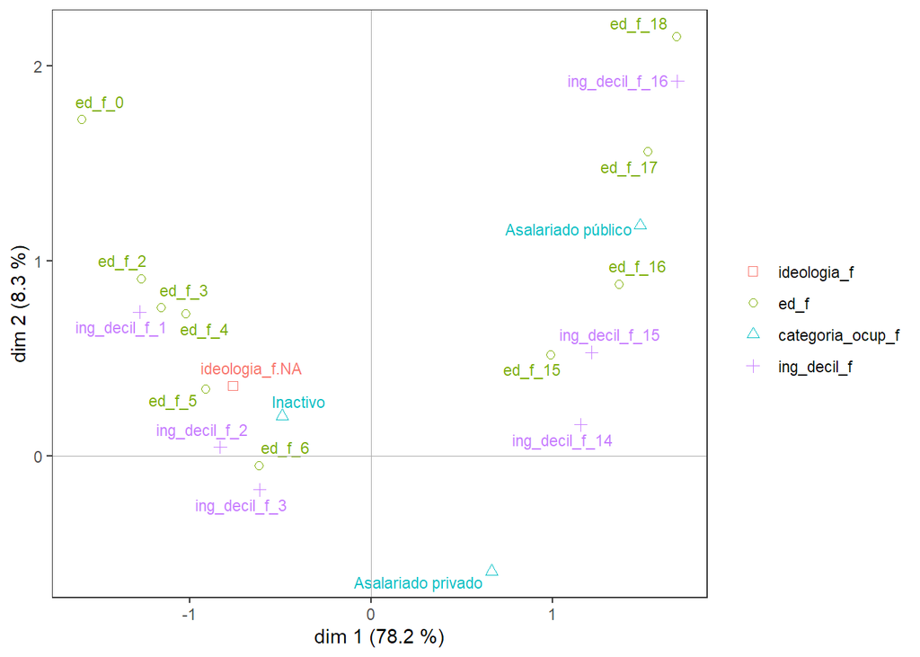

```r
#MCA
lapop2004_2018$ed_f <- factor(lapop2004_2018$ed, labels = c(0:18))
lapop2004_2018$ing_decil_f <- factor(lapop2004_2018$ing_decil, labels = c(0:16))
lapop2004_2018$ideologia_f <- factor(lapop2004_2018$ideologia, labels = c(1:10))

variables_mca <- lapop2004_2018 %>%
  select(ideologia_f, ed_f, categoria_ocup_f, ing_decil_f)

mca2 <- MCA(variables_mca, ncp = 2, graph = F)

ggcloud_variables(mca2, vlab = F, shapes = T, shapesize = 2, points = "besth")
```

Los casos perdidos en la variable *ideología* se encuentran muy asociaciados al nivel educativo bajo y a los ingresos bajos. Nuevamente, como en el caso de las variables objetivo, lo mejor sería imputarlas según nivel económico, ya que está relacionada y no formará parte del modelo de regresión.

Data Frame Summary

lapop2004_2018

**Dimensions**: 66771 x 2  
**Duplicates**: 66751

| **No** | **Variable** | **Stats / Values** | **Freqs (% of Valid)** | **Graph** | **Missing** |
| --- | --- | --- | --- | --- | --- |
| 1 | ideologia [numeric] | Mean (sd) : 5.5 (2.5) min ≤ med ≤ max: 1 ≤ 6 ≤ 10 IQR (CV) : 3 (0.4) | 1 : 4863 ( 8.6% ) 2 : 2363 ( 4.2% ) 3 : 5310 ( 9.3% ) 4 : 4844 ( 8.5% ) 5 : 7295 ( 12.8% ) 6 : 14855 ( 26.1% ) 7 : 5318 ( 9.4% ) 8 : 4989 ( 8.8% ) 9 : 2380 ( 4.2% ) 10 : 4594 ( 8.1% ) |  | 9960 (14.9%) |
| 2 | ideologia_imp [numeric] | Mean (sd) : 5.5 (2.5) min ≤ med ≤ max: 1 ≤ 6 ≤ 10 IQR (CV) : 3 (0.4) | 1 : 5750 ( 8.6% ) 2 : 2791 ( 4.2% ) 3 : 6201 ( 9.3% ) 4 : 5663 ( 8.5% ) 5 : 8572 ( 12.8% ) 6 : 17539 ( 26.3% ) 7 : 6271 ( 9.4% ) 8 : 5780 ( 8.7% ) 9 : 2795 ( 4.2% ) 10 : 5409 ( 8.1% ) |  | 0 (0.0%) |

Generated by summarytools 1.0.1 ([R](https://www.r-project.org/) version 4.2.1)  
2022-09-16

# Problema variable Tranferencias Condicionadas

Ayuda gobierno x Transferencias condicionadas. Chile 2016.

1

2

NA

Total

1

35.5%

8.7%

25.0%

11.7%

2

64.5%

91.0%

59.1%

87.7%

NA

0.2%

15.9%

0.6%

Total

100.0%

100.0%

100.0%

100.0%

Ayuda gobierno x Transferencias condicionadas. Todos los países 2016.

| wf1 | 1 | 2 | NA | Total |
| --- | --- | --- | --- | --- |
| 1 | 36.4% | 5.5% | 19.2% | 12.0% |
| 2 | 63.1% | 94.3% | 68.0% | 87.6% |
| NA | 0.6% | 0.2% | 12.8% | 0.4% |
| Total | 100.0% | 100.0% | 100.0% | 100.0% |

Las variables de *Ayuda económica del gobierno* y *Transferencias condicionadas* parecieran no apuntar a lo mismo. Del total de familias que recibió transferencias condicionadas, solo un 35,5% indicó declarar que recibió ayuda económica del gobierno.

# Descriptivos

## Tablas resumen

| **Característica** | **2008**, N = 10,573<sup>1</sup> | **2010**, N = 11,925<sup>1</sup> | **2012**, N = 10,666<sup>1</sup> | **2014**, N = 10,626<sup>1</sup> | **2016**, N = 11,972<sup>1</sup> | **2018**, N = 11,009<sup>1</sup> | **Total**<sup>1</sup> |
| --- | --- | --- | --- | --- | --- | --- | --- |
| Acuerdo con democracia | 5.45 (1.64) | 5.39 (1.66) | 5.41 (1.62) | 5.37 (1.66) | 4.87 (1.77) | 5.00 (1.68) | 5.24 (1.69) |
| Acuerdo con políticas de reducción de desigualdad | 5.97 (1.43) | 5.98 (1.40) | 5.93 (1.38) | 5.68 (1.61) | 5.46 (1.73) | 5.34 (1.73) | 5.72 (1.58) |
| Desempleo como fenómeno voluntario | NA (NA) | NA (NA) | NA (NA) | NA (NA) | NA (NA) | 3.44 (2.00) | 3.44 (2.00) |
| Los gobiernos deben invertir en ayudar a los pobres | NA (NA) | NA (NA) | NA (NA) | NA (NA) | NA (NA) | 5.53 (1.75) | 5.53 (1.75) |
| Injusto que los ricos paguen altos impuestos | NA (NA) | NA (NA) | NA (NA) | NA (NA) | NA (NA) | 4.29 (1.90) | 4.29 (1.90) |
| Categoría ocupacional |  |  |  |  |  |  |  |
| Patrón | 216 (2.1%) | 201 (1.7%) | 165 (1.6%) | 149 (1.4%) | 258 (2.2%) | 260 (2.4%) | 1,249 (1.9%) |
| Asalariado público | 801 (7.7%) | 878 (7.4%) | 815 (7.7%) | 732 (6.9%) | 878 (7.4%) | 765 (7.0%) | 4,869 (7.4%) |
| Asalariado privado | 2,394 (22.9%) | 2,514 (21.3%) | 2,490 (23.5%) | 2,407 (22.8%) | 2,156 (18.2%) | 2,086 (19.2%) | 14,047 (21.2%) |
| Cuenta propia | 2,192 (21.0%) | 2,765 (23.4%) | 2,513 (23.7%) | 2,509 (23.8%) | 2,836 (23.9%) | 2,333 (21.5%) | 15,148 (22.9%) |
| Desocupado | 640 (6.1%) | 943 (8.0%) | 619 (5.8%) | 504 (4.8%) | 1,339 (11.3%) | 1,232 (11.3%) | 5,277 (8.0%) |
| Inactivo | 4,199 (40.2%) | 4,509 (38.2%) | 3,981 (37.6%) | 4,258 (40.3%) | 4,398 (37.1%) | 4,198 (38.6%) | 25,543 (38.6%) |
| Formalidad |  |  |  |  |  |  |  |
| Formal | 0 (NA%) | 0 (NA%) | 0 (NA%) | 0 (NA%) | 0 (NA%) | 2,954 (27.0%) | 2,954 (27.0%) |
| Informal | 0 (NA%) | 0 (NA%) | 0 (NA%) | 0 (NA%) | 0 (NA%) | 2,649 (24.2%) | 2,649 (24.2%) |
| Desocupado | 0 (NA%) | 0 (NA%) | 0 (NA%) | 0 (NA%) | 0 (NA%) | 1,132 (10.4%) | 1,132 (10.4%) |
| Inactivo | 0 (NA%) | 0 (NA%) | 0 (NA%) | 0 (NA%) | 0 (NA%) | 4,198 (38.4%) | 4,198 (38.4%) |
| Estatus ocupacional |  |  |  |  |  |  |  |
| Directivos-Profesionales | 0 (NA%) | 0 (NA%) | 0 (NA%) | 0 (NA%) | 0 (NA%) | 471 (4.5%) | 471 (4.5%) |
| Técnicos-administrativos-vendedores | 0 (NA%) | 0 (NA%) | 0 (NA%) | 0 (NA%) | 0 (NA%) | 631 (6.0%) | 631 (6.0%) |
| Trabajadores manuales calificados | 0 (NA%) | 0 (NA%) | 0 (NA%) | 0 (NA%) | 0 (NA%) | 2,678 (25.7%) | 2,678 (25.7%) |
| Trabajadores manuales no calificados | 0 (NA%) | 0 (NA%) | 0 (NA%) | 0 (NA%) | 0 (NA%) | 1,316 (12.6%) | 1,316 (12.6%) |
| No ocupados | 0 (NA%) | 0 (NA%) | 0 (NA%) | 0 (NA%) | 0 (NA%) | 5,337 (51.2%) | 5,337 (51.2%) |
| Ideología (der-izq) | 5.36 (2.32) | 5.45 (2.36) | 5.50 (2.42) | 5.58 (2.49) | 5.76 (2.54) | 5.60 (2.57) | 5.54 (2.46) |
| Sexo |  |  |  |  |  |  |  |
| Varón | 5,008 (47.4%) | 5,610 (47.0%) | 5,097 (47.8%) | 4,975 (46.8%) | 5,945 (49.7%) | 5,455 (49.6%) | 32,090 (48.1%) |
| Mujer | 5,565 (52.6%) | 6,315 (53.0%) | 5,569 (52.2%) | 5,651 (53.2%) | 6,026 (50.3%) | 5,552 (50.4%) | 34,678 (51.9%) |
| Edad | 41 (16) | 40 (17) | 41 (16) | 42 (17) | 41 (16) | 42 (17) | 41 (17) |
| Años educativos | 9.3 (4.3) | 9.6 (4.2) | 9.8 (4.1) | 9.8 (4.1) | 10.2 (4.0) | 10.4 (4.1) | 9.9 (4.2) |
| Región |  |  |  |  |  |  |  |
| 1 | 0 (NA%) | 0 (NA%) | 0 (NA%) | 0 (NA%) | 0 (NA%) | 9,291 (84.4%) | 9,291 (84.4%) |
| 2 | 0 (NA%) | 0 (NA%) | 0 (NA%) | 0 (NA%) | 0 (NA%) | 1,718 (15.6%) | 1,718 (15.6%) |
| Nivel de desempleo | 7.14 (1.80) | 7.56 (2.03) | 6.32 (1.48) | 6.32 (1.34) | 6.98 (2.35) | 7.77 (2.85) | 7.03 (2.12) |
| Nivel de informalidad | 46 (14) | 45 (13) | 43 (14) | 43 (14) | 45 (14) | 43 (13) | 44 (14) |
| Nivel de empleo público | 11.1 (3.4) | 11.4 (3.5) | 11.5 (4.0) | 11.4 (4.0) | 11.2 (4.2) | 11.4 (4.4) | 11.3 (3.9) |
| Brecha informales / asalariados reg. | 50.3 (6.7) | 51.6 (7.7) | 50.6 (7.2) | 50.6 (6.4) | 50.0 (5.3) | 49.9 (5.9) | 50.5 (6.6) |
| País |  |  |  |  |  |  |  |
| Argentina | 1,486 (14.1%) | 1,410 (11.8%) | 1,512 (14.2%) | 1,512 (14.2%) | 1,528 (12.8%) | 1,528 (13.9%) | 8,976 (13.4%) |
| Brasil | 1,497 (14.2%) | 2,482 (20.8%) | 1,499 (14.1%) | 1,500 (14.1%) | 1,532 (12.8%) | 1,498 (13.6%) | 10,008 (15.0%) |
| Chile | 1,527 (14.4%) | 1,965 (16.5%) | 1,571 (14.7%) | 1,571 (14.8%) | 1,625 (13.6%) | 1,638 (14.9%) | 9,897 (14.8%) |
| Colombia | 1,503 (14.2%) | 1,506 (12.6%) | 1,512 (14.2%) | 1,496 (14.1%) | 1,563 (13.1%) | 1,663 (15.1%) | 9,243 (13.8%) |
| México | 1,560 (14.8%) | 1,562 (13.1%) | 1,560 (14.6%) | 1,535 (14.4%) | 1,563 (13.1%) | 1,580 (14.4%) | 9,360 (14.0%) |
| Perú | 1,500 (14.2%) | 1,500 (12.6%) | 1,500 (14.1%) | 1,500 (14.1%) | 2,647 (22.1%) | 1,521 (13.8%) | 10,168 (15.2%) |
| Uruguay | 1,500 (14.2%) | 1,500 (12.6%) | 1,512 (14.2%) | 1,512 (14.2%) | 1,514 (12.6%) | 1,581 (14.4%) | 9,119 (13.7%) |

<sup>1</sup> Media (DE); n (%)

## Boxplot y gráficos de medias (año y país)

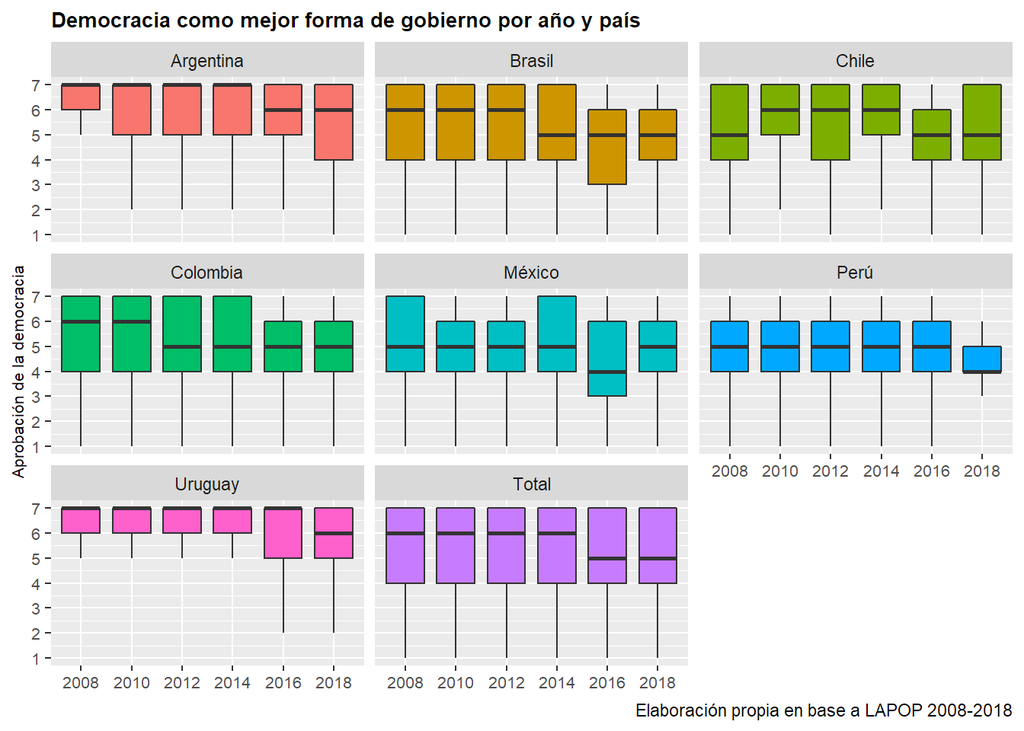

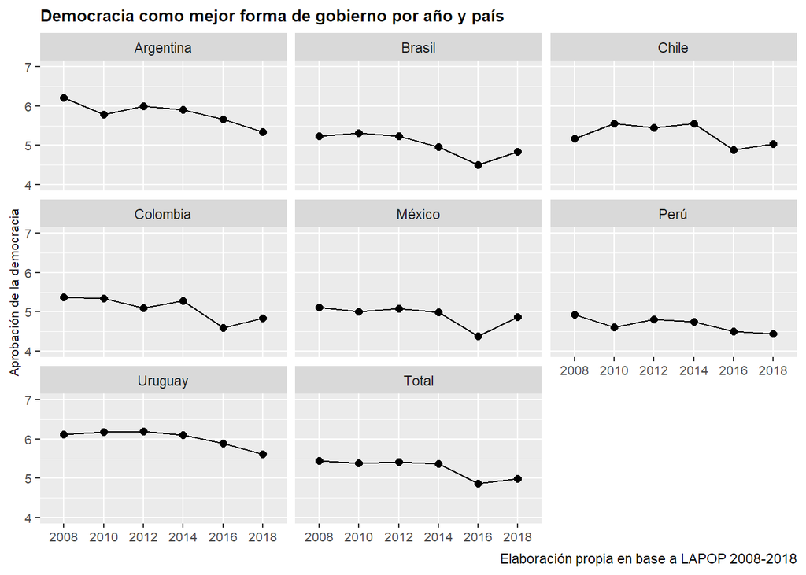

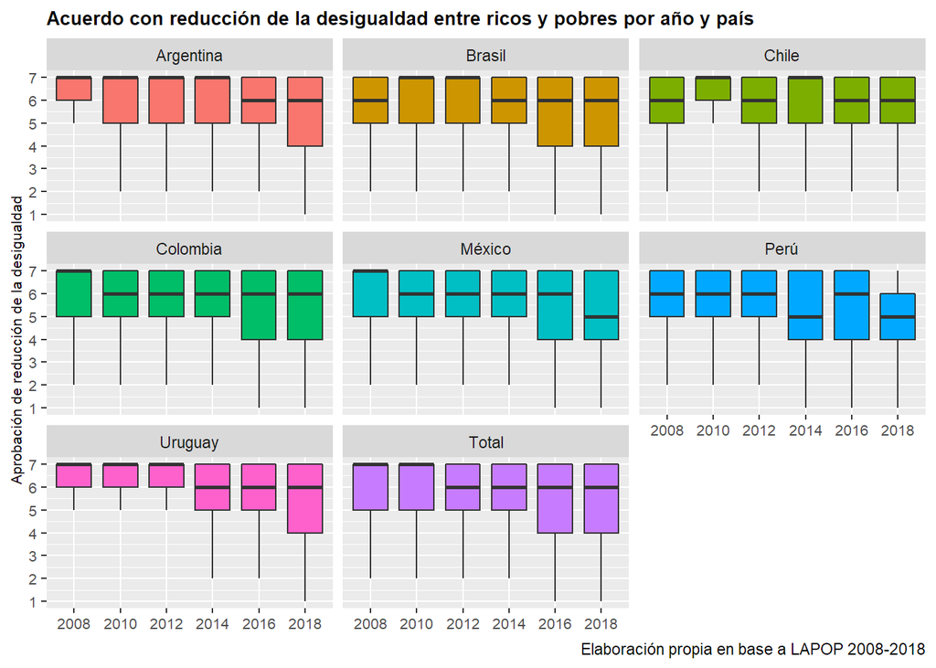

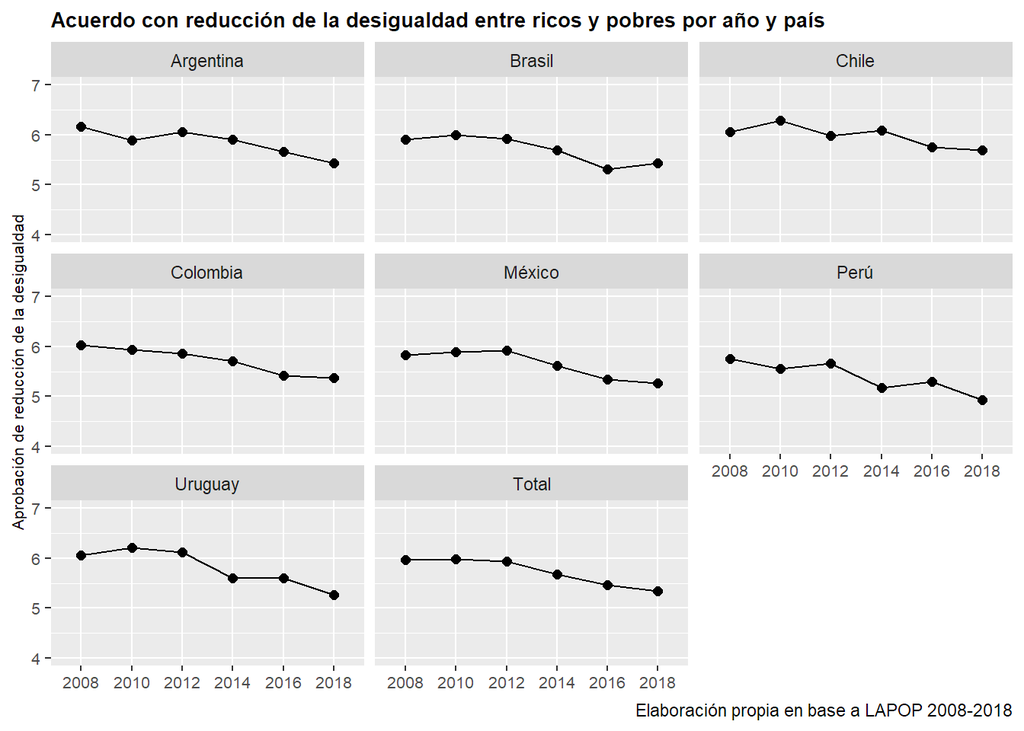

## Boxplot 2018

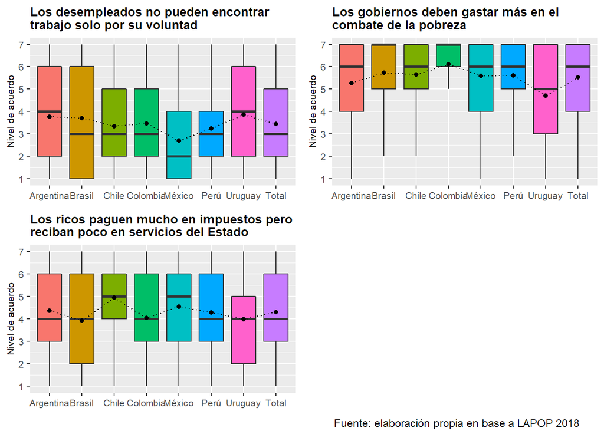

# Descriptivos variables independientes

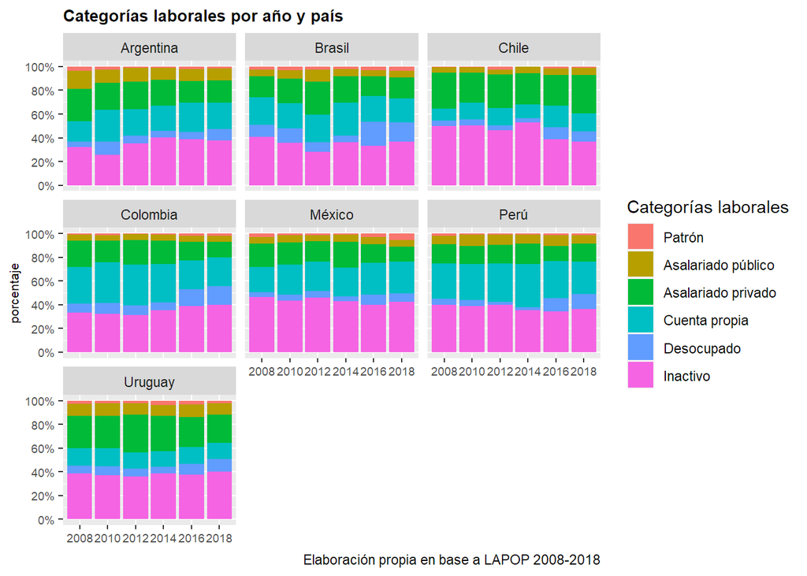

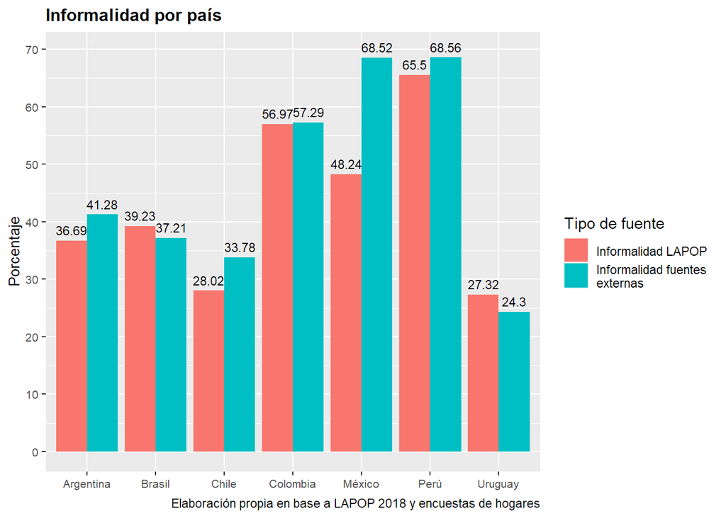

# Cruces variable laboral y variables objetivo 2008-2018

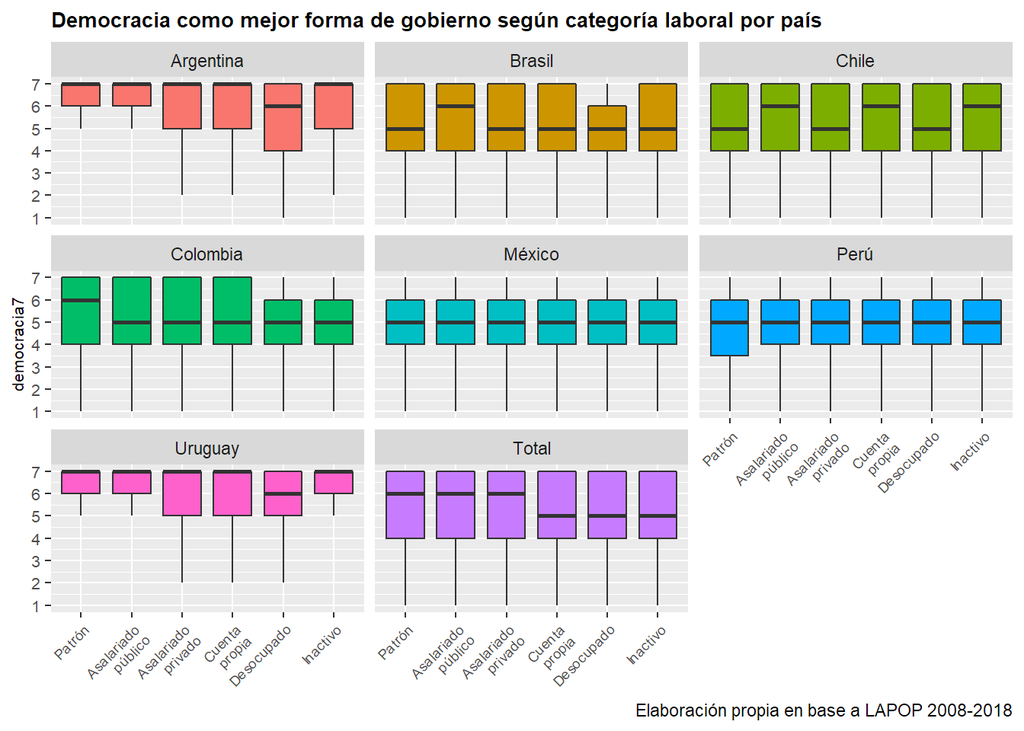

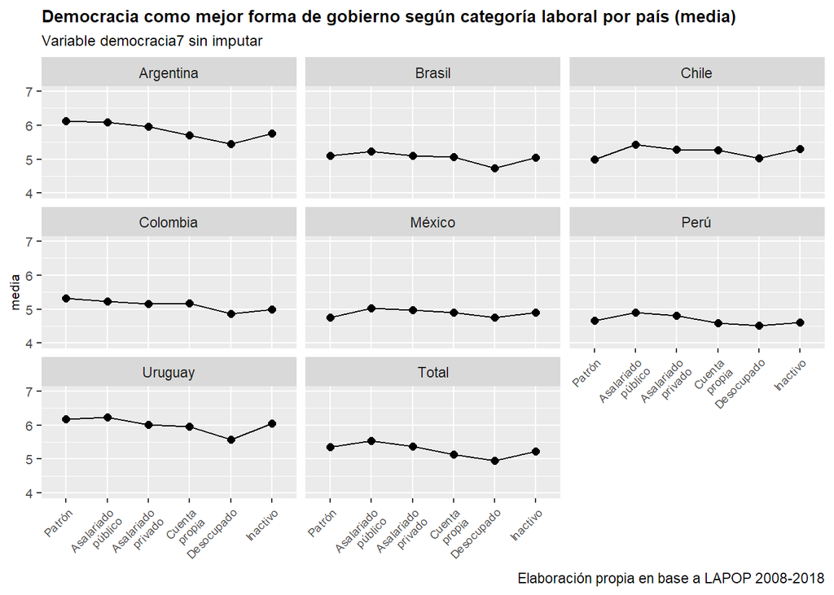

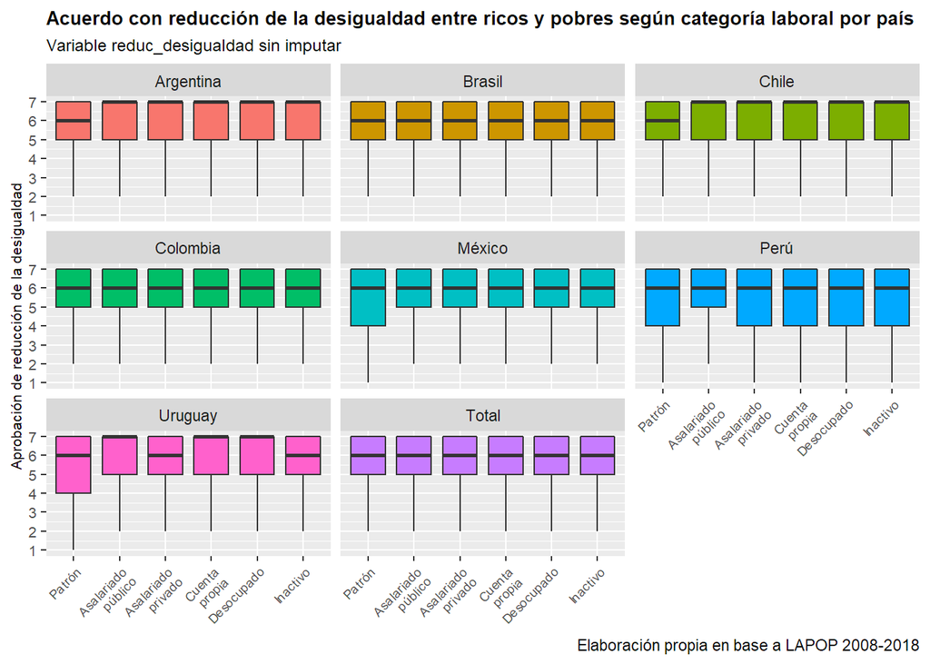

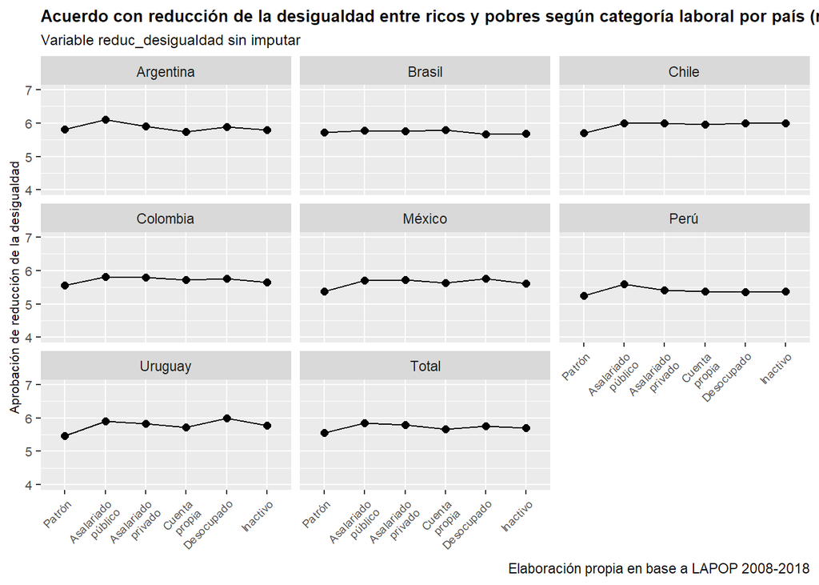

# Cruces variable laboral / informal y variables objetivo 2018

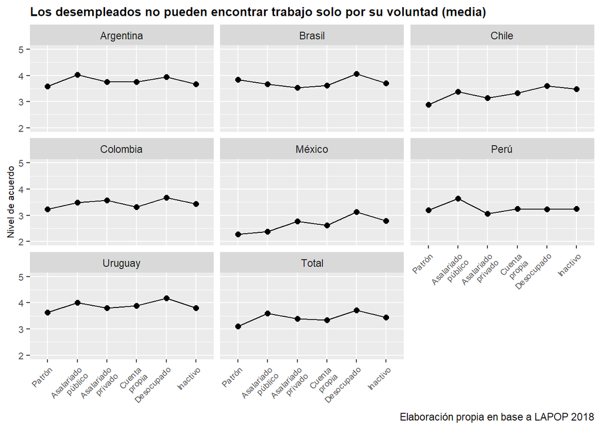

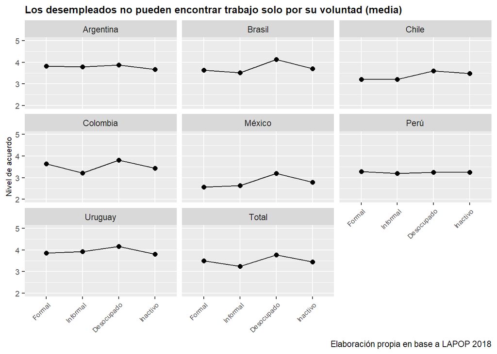

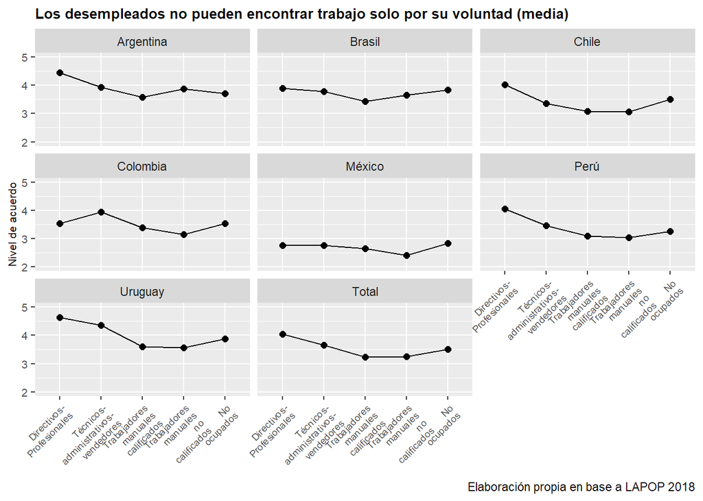

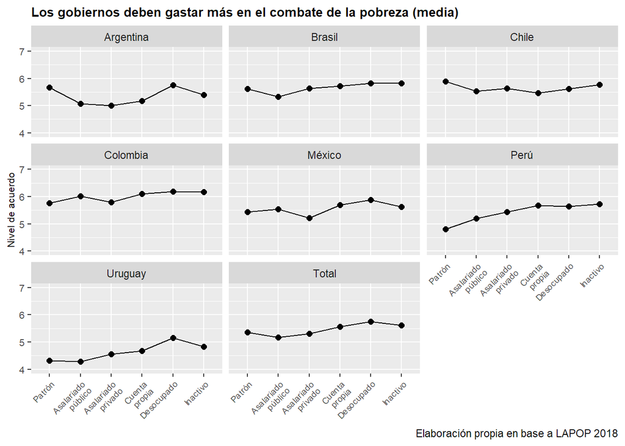

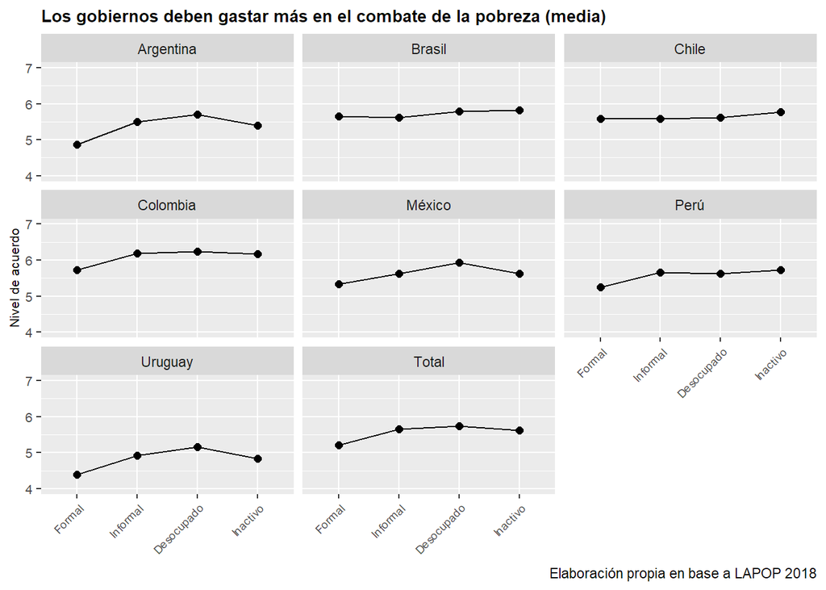

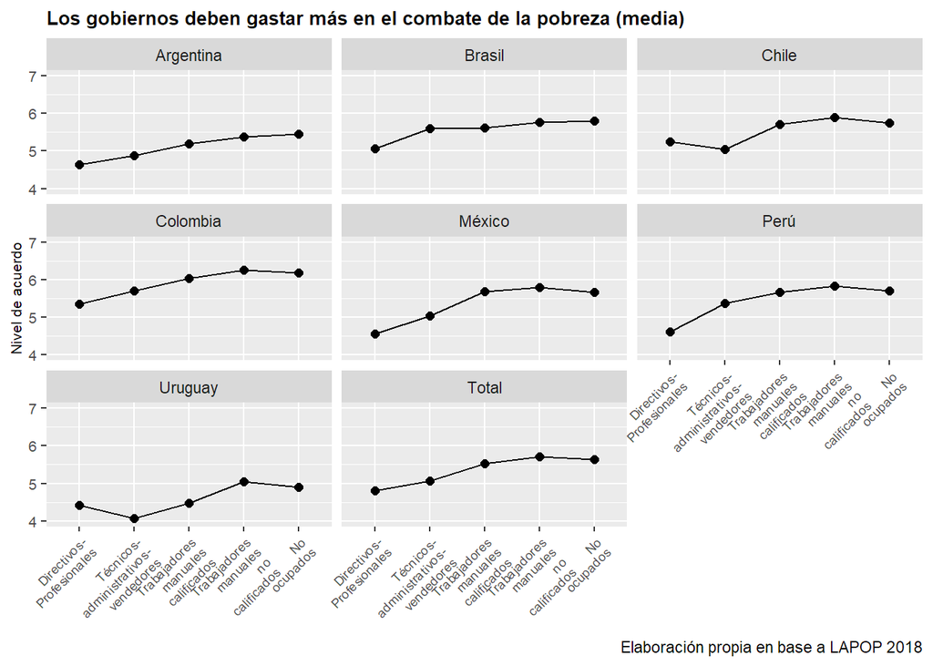

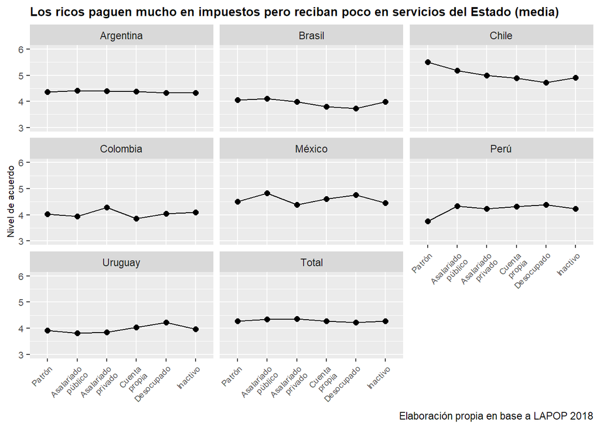

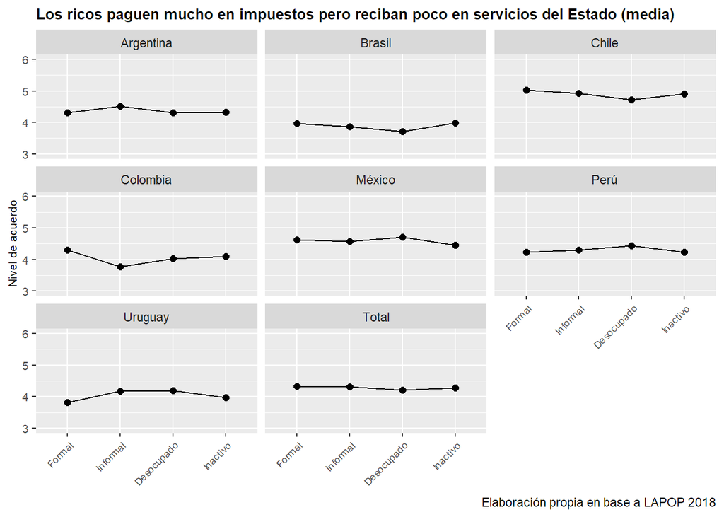

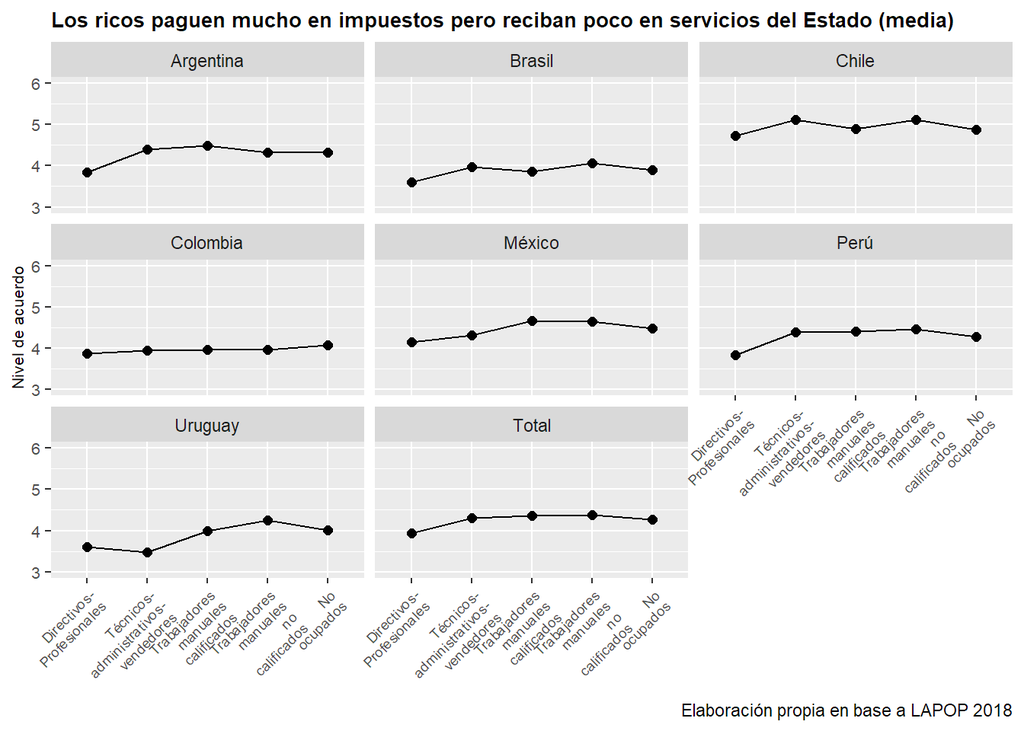

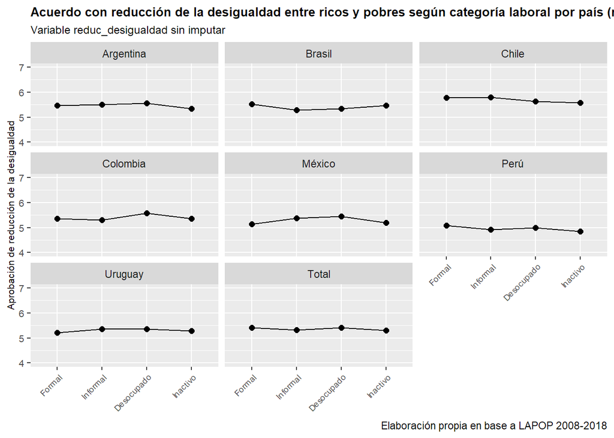

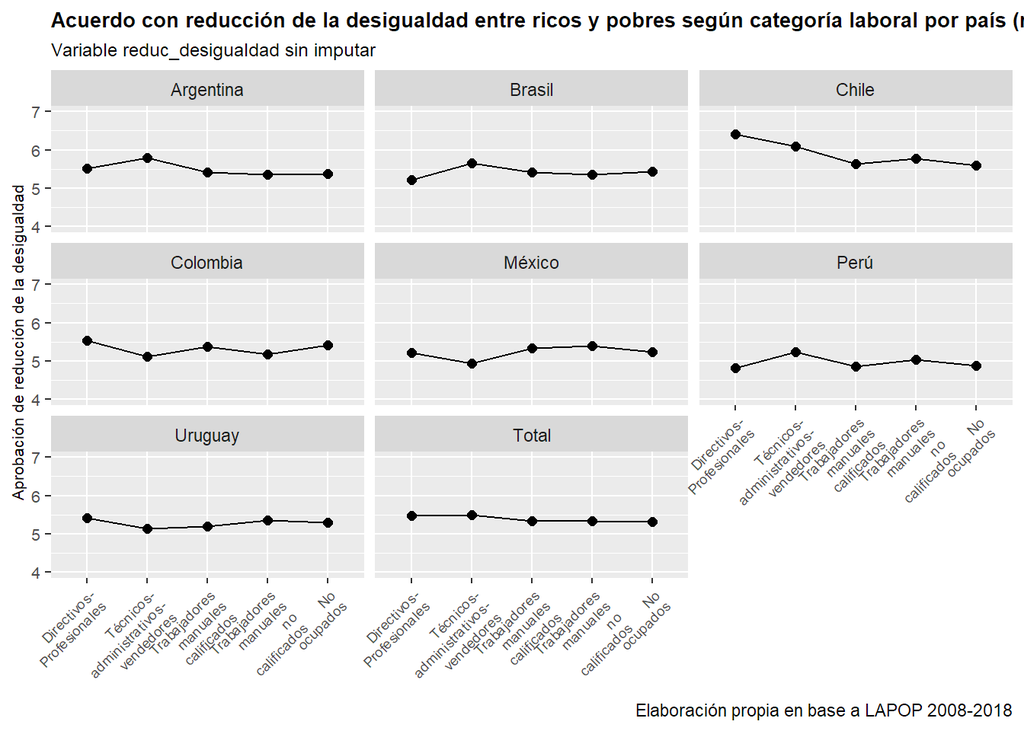

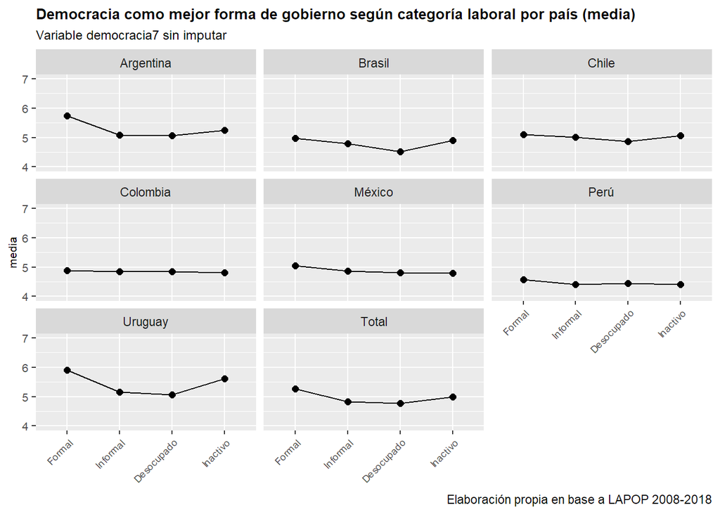

[1 more figures not shown]

# Modelos Multinivel 2008-2018

El **ICC** para la variable objetivo de *acuerdo con la democracia* es de **0.095**.

El **ICC** para la variable objetivo de *reducción de la desigualdad* es de **0.04**.

Democracia

|  | Ind | Ind + grup | Ind + grup + int | Random_apub | Random_apri | Random_cuent | Random_desoc |
| --- | --- | --- | --- | --- | --- | --- | --- |
| Intercepto | 5.26*** | 5.25*** | 5.25*** | 5.25*** | 5.25*** | 5.25*** | 5.25*** |
|  | (0.08) | (0.06) | (0.06) | (0.06) | (0.06) | (0.06) | (0.06) |
| Patrón | 0.00 | 0.00 | 0.00 | 0.00 | 0.00 | 0.00 | 0.00 |
|  | (0.05) | (0.05) | (0.05) | (0.05) | (0.05) | (0.05) | (0.05) |
| Asalariado pub. | 0.06* | 0.06* | 0.06* | 0.06 | 0.06* | 0.06* | 0.06* |
|  | (0.03) | (0.03) | (0.03) | (0.04) | (0.03) | (0.03) | (0.03) |
| Asalariado priv. | 0.05** | 0.05** | 0.05** | 0.05** | 0.05* | 0.05** | 0.05** |
|  | (0.02) | (0.02) | (0.02) | (0.02) | (0.02) | (0.02) | (0.02) |
| Cuenta propia | -0.01 | -0.01 | -0.01 | -0.01 | -0.01 | -0.01 | -0.01 |
|  | (0.02) | (0.02) | (0.02) | (0.02) | (0.02) | (0.02) | (0.02) |
| Desocupado | -0.11*** | -0.11*** | -0.10*** | -0.10*** | -0.10*** | -0.10*** | -0.10*** |
|  | (0.03) | (0.03) | (0.03) | (0.03) | (0.03) | (0.03) | (0.03) |
| Ideología (der-izq) | -0.02*** | -0.02*** | -0.02*** | -0.02*** | -0.02*** | -0.02*** | -0.02*** |
|  | (0.00) | (0.00) | (0.00) | (0.00) | (0.00) | (0.00) | (0.00) |
| Varón | 0.07*** | 0.07*** | 0.07*** | 0.07*** | 0.07*** | 0.07*** | 0.07*** |
|  | (0.01) | (0.01) | (0.01) | (0.01) | (0.01) | (0.01) | (0.01) |
| Edad | 0.01*** | 0.01*** | 0.01*** | 0.01*** | 0.01*** | 0.01*** | 0.01*** |
|  | (0.00) | (0.00) | (0.00) | (0.00) | (0.00) | (0.00) | (0.00) |
| Años educ. | 0.06*** | 0.06*** | 0.06*** | 0.06*** | 0.06*** | 0.06*** | 0.06*** |
|  | (0.00) | (0.00) | (0.00) | (0.00) | (0.00) | (0.00) | (0.00) |
| Desempleo |  | -0.02 | -0.02 | -0.01 | -0.02 | -0.04 | -0.02 |
|  |  | (0.03) | (0.03) | (0.03) | (0.03) | (0.03) | (0.03) |
| Informalidad |  | -0.03*** | -0.03*** | -0.04*** | -0.03*** | -0.03*** | -0.03*** |
|  |  | (0.01) | (0.01) | (0.01) | (0.01) | (0.01) | (0.01) |
| Empleo pub. |  | 0.04 | 0.04 | 0.05* | 0.05* | 0.05* | 0.04* |
|  |  | (0.02) | (0.02) | (0.02) | (0.02) | (0.02) | (0.02) |
| Brecha remun. |  | -0.05*** | -0.05*** | -0.06*** | -0.05*** | -0.05*** | -0.05*** |
|  |  | (0.01) | (0.01) | (0.01) | (0.01) | (0.01) | (0.01) |
| Desocupado*desempleo |  |  | -0.03** | -0.03** | -0.03** | -0.03* | -0.03* |
|  |  |  | (0.01) | (0.01) | (0.01) | (0.01) | (0.01) |
| AIC | 233260.64 | 233261.74 | 233264.08 | 233248.86 | 233259.38 | 233263.69 | 233266.84 |
| BIC | 233369.07 | 233406.31 | 233417.69 | 233420.55 | 233431.06 | 233435.37 | 233438.52 |
| Log Likelihood | -116618.32 | -116614.87 | -116615.04 | -116605.43 | -116610.69 | -116612.85 | -116614.42 |
| Num. obs. | 62060 | 62060 | 62060 | 62060 | 62060 | 62060 | 62060 |
| Num. groups: pais_anio | 42 | 42 | 42 | 42 | 42 | 42 | 42 |
| Var: pais_anio (Intercept) | 0.27 | 0.13 | 0.13 | 0.13 | 0.13 | 0.13 | 0.13 |
| Var: Residual | 2.50 | 2.50 | 2.50 | 2.50 | 2.50 | 2.50 | 2.50 |
| Var: pais_anio asal_pub_cwc |  |  |  | 0.02 |  |  |  |
| Cov: pais_anio (Intercept) asal_pub_cwc |  |  |  | -0.03 |  |  |  |
| Var: pais_anio asal_pri_cwc |  |  |  |  | 0.01 |  |  |
| Cov: pais_anio (Intercept) asal_pri_cwc |  |  |  |  | -0.01 |  |  |
| Var: pais_anio cuenta_prop_cwc |  |  |  |  |  | 0.00 |  |
| Cov: pais_anio (Intercept) cuenta_prop_cwc |  |  |  |  |  | 0.01 |  |
| Var: pais_anio desocupado_cwc |  |  |  |  |  |  | 0.00 |
| Cov: pais_anio (Intercept) desocupado_cwc |  |  |  |  |  |  | 0.01 |

***p < 0.001; **p < 0.01; *p < 0.05

```
## Data: base_ml
## Models:
## democracia_null: democracia7 ~ 1 + (1 | pais_anio)
## democracia_ind: democracia7 ~ 1 + patron_cwc + asal_pub_cwc + asal_pri_cwc + cuenta_prop_cwc + desocupado_cwc + ideologia_cwc + sexo_cwc + edad_cwc + educ_cwc + (1 | pais_anio)
##                 npar    AIC    BIC  logLik deviance  Chisq Df Pr(>Chisq)
## democracia_null    3 234949 234976 -117472   234943
## democracia_ind    12 233188 233296 -116582   233164 1779.5  9  < 2.2e-16 ***
## ---
## Signif. codes:  0 '***' 0.001 '**' 0.01 '*' 0.05 '.' 0.1 ' ' 1
```

```
## Data: base_ml
## Models:
## democracia_ind: democracia7 ~ 1 + patron_cwc + asal_pub_cwc + asal_pri_cwc + cuenta_prop_cwc + desocupado_cwc + ideologia_cwc + sexo_cwc + edad_cwc + educ_cwc + (1 | pais_anio)
## democracia_ind_grup: democracia7 ~ 1 + patron_cwc + asal_pub_cwc + asal_pri_cwc + cuenta_prop_cwc + desocupado_cwc + ideologia_cwc + sexo_cwc + edad_cwc + educ_cwc + desempleo_cgm + informalidad_cgm + empleo_pub_cgm + brecha_remun_cgm + (1 | pais_anio)
##                     npar    AIC    BIC  logLik deviance  Chisq Df Pr(>Chisq)
## democracia_ind        12 233188 233296 -116582   233164
## democracia_ind_grup   16 233161 233305 -116564   233129 34.879  4   4.92e-07
##
## democracia_ind
## democracia_ind_grup ***
## ---
## Signif. codes:  0 '***' 0.001 '**' 0.01 '*' 0.05 '.' 0.1 ' ' 1
```

```
## Data: base_ml
## Models:
## democracia_ind_grup: democracia7 ~ 1 + patron_cwc + asal_pub_cwc + asal_pri_cwc + cuenta_prop_cwc + desocupado_cwc + ideologia_cwc + sexo_cwc + edad_cwc + educ_cwc + desempleo_cgm + informalidad_cgm + empleo_pub_cgm + brecha_remun_cgm + (1 | pais_anio)
## democracia_ind_grup_int: democracia7 ~ 1 + patron_cwc + asal_pub_cwc + asal_pri_cwc + cuenta_prop_cwc + desocupado_cwc + ideologia_cwc + sexo_cwc + edad_cwc + educ_cwc + desempleo_cgm + informalidad_cgm + empleo_pub_cgm + brecha_remun_cgm + desocupado_cwc * desempleo_cgm + (1 | pais_anio)
##                         npar    AIC    BIC  logLik deviance  Chisq Df
## democracia_ind_grup       16 233161 233305 -116564   233129
## democracia_ind_grup_int   17 233156 233309 -116561   233122 6.9751  1
##                         Pr(>Chisq)
## democracia_ind_grup
## democracia_ind_grup_int   0.008265 **
## ---
## Signif. codes:  0 '***' 0.001 '**' 0.01 '*' 0.05 '.' 0.1 ' ' 1
```

```
## Data: base_ml
## Models:
## democracia_ind_grup_int: democracia7 ~ 1 + patron_cwc + asal_pub_cwc + asal_pri_cwc + cuenta_prop_cwc + desocupado_cwc + ideologia_cwc + sexo_cwc + edad_cwc + educ_cwc + desempleo_cgm + informalidad_cgm + empleo_pub_cgm + brecha_remun_cgm + desocupado_cwc * desempleo_cgm + (1 | pais_anio)
## democracia_random_apub: democracia7 ~ 1 + patron_cwc + asal_pub_cwc + asal_pri_cwc + cuenta_prop_cwc + desocupado_cwc + ideologia_cwc + sexo_cwc + edad_cwc + educ_cwc + desempleo_cgm + informalidad_cgm + empleo_pub_cgm + brecha_remun_cgm + desocupado_cwc * desempleo_cgm + (1 + asal_pub_cwc | pais…
##                         npar    AIC    BIC  logLik deviance  Chisq Df
## democracia_ind_grup_int   17 233156 233309 -116561   233122
## democracia_random_apub    19 233140 233312 -116551   233102 19.468  2
##                         Pr(>Chisq)
## democracia_ind_grup_int
## democracia_random_apub   5.922e-05 ***
## ---
## Signif. codes:  0 '***' 0.001 '**' 0.01 '*' 0.05 '.' 0.1 ' ' 1
```

```
## Data: base_ml
## Models:
## democracia_ind_grup_int: democracia7 ~ 1 + patron_cwc + asal_pub_cwc + asal_pri_cwc + cuenta_prop_cwc + desocupado_cwc + ideologia_cwc + sexo_cwc + edad_cwc + educ_cwc + desempleo_cgm + informalidad_cgm + empleo_pub_cgm + brecha_remun_cgm + desocupado_cwc * desempleo_cgm + (1 | pais_anio)
## democracia_random_apri: democracia7 ~ 1 + patron_cwc + asal_pub_cwc + asal_pri_cwc + cuenta_prop_cwc + desocupado_cwc + ideologia_cwc + sexo_cwc + edad_cwc + educ_cwc + desempleo_cgm + informalidad_cgm + empleo_pub_cgm + brecha_remun_cgm + desocupado_cwc * desempleo_cgm + (1 + asal_pri_cwc | pais…
##                         npar    AIC    BIC  logLik deviance Chisq Df Pr(>Chisq)
## democracia_ind_grup_int   17 233156 233309 -116561   233122
## democracia_random_apri    19 233151 233323 -116557   233113 8.463  2    0.01453
##
## democracia_ind_grup_int
## democracia_random_apri  *
## ---
## Signif. codes:  0 '***' 0.001 '**' 0.01 '*' 0.05 '.' 0.1 ' ' 1
```

```
## Data: base_ml
## Models:
## democracia_ind_grup_int: democracia7 ~ 1 + patron_cwc + asal_pub_cwc + asal_pri_cwc + cuenta_prop_cwc + desocupado_cwc + ideologia_cwc + sexo_cwc + edad_cwc + educ_cwc + desempleo_cgm + informalidad_cgm + empleo_pub_cgm + brecha_remun_cgm + desocupado_cwc * desempleo_cgm + (1 | pais_anio)
## democracia_random_cuent: democracia7 ~ 1 + patron_cwc + asal_pub_cwc + asal_pri_cwc + cuenta_prop_cwc + desocupado_cwc + ideologia_cwc + sexo_cwc + edad_cwc + educ_cwc + desempleo_cgm + informalidad_cgm + empleo_pub_cgm + brecha_remun_cgm + desocupado_cwc * desempleo_cgm + (1 + cuenta_prop_cwc | …
##                         npar    AIC    BIC  logLik deviance  Chisq Df
## democracia_ind_grup_int   17 233156 233309 -116561   233122
## democracia_random_cuent   19 233155 233327 -116559   233117 4.5617  2
##                         Pr(>Chisq)
## democracia_ind_grup_int
## democracia_random_cuent     0.1022
```

```
## Data: base_ml
## Models:
## democracia_ind_grup_int: democracia7 ~ 1 + patron_cwc + asal_pub_cwc + asal_pri_cwc + cuenta_prop_cwc + desocupado_cwc + ideologia_cwc + sexo_cwc + edad_cwc + educ_cwc + desempleo_cgm + informalidad_cgm + empleo_pub_cgm + brecha_remun_cgm + desocupado_cwc * desempleo_cgm + (1 | pais_anio)
## democracia_random_desoc: democracia7 ~ 1 + patron_cwc + asal_pub_cwc + asal_pri_cwc + cuenta_prop_cwc + desocupado_cwc + ideologia_cwc + sexo_cwc + edad_cwc + educ_cwc + desempleo_cgm + informalidad_cgm + empleo_pub_cgm + brecha_remun_cgm + desocupado_cwc * desempleo_cgm + (1 + desocupado_cwc | p…
##                         npar    AIC    BIC  logLik deviance  Chisq Df
## democracia_ind_grup_int   17 233156 233309 -116561   233122
## democracia_random_desoc   19 233159 233330 -116560   233121 1.2147  2
##                         Pr(>Chisq)
## democracia_ind_grup_int
## democracia_random_desoc     0.5448
```

**Importante**  
El test de devianza muestra que los modelos de pendiente aleatoria para los **cuentapropia** y para **desocupados** no mejoran el ajuste. El pseudo r2 para el segundo nivel (países años)

- en el modelo con predictores individuales es de **-1.8449195^{-4}**,
- en el modelo de predictores individuales y grupales es de **0.5201849**,
- en el modelo con interacciones es de **0.5201866**,
- en el los modelos de pendiente aleatoria es de **0.5082107**.

Reducción de la desigualdad

|  | Ind | Ind+grup |
| --- | --- | --- |
| Intercepto | 5.73*** | 5.73*** |
|  | (0.05) | (0.05) |
| Patrón | -0.09 | -0.09 |
|  | (0.05) | (0.05) |
| Asalariado pub. | 0.14*** | 0.14*** |
|  | (0.03) | (0.03) |
| Asalariado priv. | 0.05** | 0.05** |
|  | (0.02) | (0.02) |
| Cuenta propia | 0.02 | 0.02 |
|  | (0.02) | (0.02) |
| Desocupado | 0.13*** | 0.13*** |
|  | (0.02) | (0.02) |
| Ideología (der-izq) | 0.02*** | 0.02*** |
|  | (0.00) | (0.00) |
| Varón | -0.00 | -0.00 |
|  | (0.01) | (0.01) |
| Edad | 0.00 | 0.00 |
|  | (0.00) | (0.00) |
| Años educ. | 0.00** | 0.00** |
|  | (0.00) | (0.00) |
| Desempleo |  | 0.01 |
|  |  | (0.03) |
| Informalidad |  | -0.01 |
|  |  | (0.01) |
| Empleo pub. |  | -0.01 |
|  |  | (0.02) |
| Brecha remun. |  | 0.00 |
|  |  | (0.01) |
| AIC | 229750.90 | 229779.99 |
| BIC | 229859.33 | 229924.56 |
| Log Likelihood | -114863.45 | -114873.99 |
| Num. obs. | 62060 | 62060 |
| Num. groups: pais_anio | 42 | 42 |
| Var: pais_anio (Intercept) | 0.10 | 0.09 |
| Var: Residual | 2.36 | 2.36 |

***p < 0.001; **p < 0.01; *p < 0.05

```
## Data: base_ml
## Models:
## reduc_desigualdad_null: reduc_desigualdad ~ 1 + (1 | pais_anio)
## reduc_desigualdad_ind: reduc_desigualdad ~ 1 + patron_cwc + asal_pub_cwc + asal_pri_cwc + cuenta_prop_cwc + desocupado_cwc + ideologia_cwc + sexo_cwc + edad_cwc + educ_cwc + (1 | pais_anio)
##                        npar    AIC    BIC  logLik deviance  Chisq Df Pr(>Chisq)
## reduc_desigualdad_null    3 229809 229836 -114902   229803
## reduc_desigualdad_ind    12 229676 229785 -114826   229652 150.72  9  < 2.2e-16
##
## reduc_desigualdad_null
## reduc_desigualdad_ind  ***
## ---
## Signif. codes:  0 '***' 0.001 '**' 0.01 '*' 0.05 '.' 0.1 ' ' 1
```

```
## Data: base_ml
## Models:
## reduc_desigualdad_ind: reduc_desigualdad ~ 1 + patron_cwc + asal_pub_cwc + asal_pri_cwc + cuenta_prop_cwc + desocupado_cwc + ideologia_cwc + sexo_cwc + edad_cwc + educ_cwc + (1 | pais_anio)
## reduc_desigualdad_ind_grup: reduc_desigualdad ~ 1 + patron_cwc + asal_pub_cwc + asal_pri_cwc + cuenta_prop_cwc + desocupado_cwc + ideologia_cwc + sexo_cwc + edad_cwc + educ_cwc + desempleo_cgm + informalidad_cgm + empleo_pub_cgm + brecha_remun_cgm + (1 | pais_anio)
##                            npar    AIC    BIC  logLik deviance  Chisq Df
## reduc_desigualdad_ind        12 229676 229785 -114826   229652
## reduc_desigualdad_ind_grup   16 229677 229821 -114822   229645 7.6622  4
##                            Pr(>Chisq)
## reduc_desigualdad_ind
## reduc_desigualdad_ind_grup     0.1048
```

**Importante**  
Para la variable objetivo *reducción de la desigualdad* la prueba de devianza muestra que el modelo con variables contextuales agregadas no mejora el ajuste por sobre el modelo de variables individuales.

# Modelos de efectos fijos (2018)

## Utilizando todas las variables laborales

Con variables laborales

|  | Democracia | Desigualdad | Desempleados | Ayuda pobres | Impuestos ricos |
| --- | --- | --- | --- | --- | --- |
| categoria_ocup_fPatrón | -0.21 | -0.11 | 0.14 | 0.05 | 0.01 |
|  | (0.21) | (0.22) | (0.25) | (0.22) | (0.24) |
| categoria_ocup_fAsalariado público | -0.31 | 0.08 | 0.30 | 0.19 | 0.13 |
|  | (0.20) | (0.21) | (0.24) | (0.20) | (0.23) |
| categoria_ocup_fAsalariado privado | -0.26 | 0.04 | 0.31 | 0.10 | -0.03 |
|  | (0.19) | (0.20) | (0.23) | (0.19) | (0.22) |
| categoria_ocup_fCuenta propia | -0.18 | -0.07 | 0.41 | 0.10 | -0.10 |
|  | (0.19) | (0.19) | (0.22) | (0.19) | (0.21) |
| categoria_ocup_fDesocupado | -0.11 | 0.10 | 0.27*** | 0.08 | 0.05 |
|  | (0.06) | (0.06) | (0.07) | (0.06) | (0.07) |
| formal_estado2Formal | -0.17 | -0.12 | 0.90 | 0.56 | -1.25 |
|  | (0.61) | (0.65) | (0.74) | (0.63) | (0.71) |
| formal_estado2Informal | -0.30 | 0.02 | 0.95 | 0.66 | -1.26 |
|  | (0.61) | (0.65) | (0.74) | (0.63) | (0.71) |
| estatus_ocup_fDirectivos-Profesionales | 0.49 | 0.04 | -1.02 | -0.92 | 0.98 |
|  | (0.64) | (0.68) | (0.77) | (0.66) | (0.74) |
| estatus_ocup_fTécnicos-administrativos-vendedores | 0.45 | 0.12 | -1.25 | -0.94 | 1.31 |
|  | (0.64) | (0.68) | (0.77) | (0.66) | (0.74) |
| estatus_ocup_fTrabajadores manuales calificados | 0.39 | 0.06 | -1.48 | -0.81 | 1.38 |
|  | (0.63) | (0.67) | (0.76) | (0.65) | (0.73) |
| estatus_ocup_fTrabajadores manuales no calificados | 0.50 | 0.14 | -1.40 | -0.73 | 1.42 |
|  | (0.63) | (0.67) | (0.76) | (0.65) | (0.73) |
| ideologia_imp | -0.02* | 0.01 | 0.06*** | 0.04*** | 0.02** |
|  | (0.01) | (0.01) | (0.01) | (0.01) | (0.01) |
| urbano | 0.04 | -0.02 | -0.14** | 0.02 | 0.03 |
|  | (0.05) | (0.05) | (0.05) | (0.05) | (0.05) |
| sexoMujer | -0.17*** | 0.00 | -0.04 | 0.02 | -0.03 |
|  | (0.03) | (0.04) | (0.04) | (0.03) | (0.04) |
| q2 | 0.02*** | 0.00 | 0.01*** | -0.01*** | 0.01*** |
|  | (0.00) | (0.00) | (0.00) | (0.00) | (0.00) |
| ed | 0.08*** | 0.04*** | 0.05*** | -0.09*** | -0.01* |
|  | (0.00) | (0.01) | (0.01) | (0.00) | (0.01) |
| R<sup>2</sup> | 0.05 | 0.01 | 0.03 | 0.05 | 0.01 |
| Adj. R<sup>2</sup> | 0.05 | 0.01 | 0.02 | 0.05 | 0.01 |
| Num. obs. | 9933 | 10142 | 10185 | 10199 | 9999 |

***p < 0.001; **p < 0.01; *p < 0.05

```
##                        GVIF Df GVIF^(1/(2*Df))
## categoria_ocup_f  53.905604  5        1.489922
## formal_estado2   563.625291  2        4.872453
## estatus_ocup_f   524.455971  4        2.187578
## ideologia_imp      1.032149  1        1.015947
## urbano             1.065313  1        1.032140
## sexo               1.102539  1        1.050018
## q2                 1.203396  1        1.096994
## ed                 1.449127  1        1.203797
## country_f          1.265574  6        1.019821
```

```
##                        GVIF Df GVIF^(1/(2*Df))
## categoria_ocup_f  53.263691  5        1.488138
## formal_estado2   575.482751  2        4.897879
## estatus_ocup_f   533.590804  4        2.192305
## ideologia_imp      1.030820  1        1.015293
## urbano             1.065696  1        1.032325
## sexo               1.104238  1        1.050827
## q2                 1.205522  1        1.097963
## ed                 1.449633  1        1.204007
## country_f          1.263722  6        1.019697
```

## Utilizando solo formalidad

Con variables laborales

|  | Democracia | Desigualdad | Desempleados | Ayuda pobres | Impuestos ricos |
| --- | --- | --- | --- | --- | --- |
| formal_estadoFormal | 0.06 | -0.01 | -0.14** | -0.16*** | 0.10* |
|  | (0.04) | (0.04) | (0.05) | (0.04) | (0.05) |
| formal_estadoInformal | -0.05 | 0.06 | -0.09 | -0.04 | 0.02 |
|  | (0.04) | (0.04) | (0.05) | (0.04) | (0.05) |
| formal_estadoDesocupado | -0.11 | 0.10 | 0.28*** | 0.08 | 0.04 |
|  | (0.06) | (0.06) | (0.07) | (0.06) | (0.07) |
| ideologia_imp | -0.02** | 0.01 | 0.07*** | 0.04*** | 0.02** |
|  | (0.01) | (0.01) | (0.01) | (0.01) | (0.01) |
| urbano | 0.04 | -0.02 | -0.12* | 0.04 | 0.04 |
|  | (0.04) | (0.05) | (0.05) | (0.05) | (0.05) |
| sexoMujer | -0.16*** | 0.01 | -0.02 | 0.01 | -0.05 |
|  | (0.03) | (0.03) | (0.04) | (0.03) | (0.04) |
| q2 | 0.02*** | 0.00 | 0.01*** | -0.01*** | 0.00*** |
|  | (0.00) | (0.00) | (0.00) | (0.00) | (0.00) |
| ed | 0.08*** | 0.04*** | 0.06*** | -0.09*** | -0.02*** |
|  | (0.00) | (0.00) | (0.01) | (0.00) | (0.01) |
| R<sup>2</sup> | 0.05 | 0.01 | 0.02 | 0.05 | 0.01 |
| Adj. R<sup>2</sup> | 0.05 | 0.01 | 0.02 | 0.05 | 0.00 |
| Num. obs. | 10519 | 10732 | 10777 | 10788 | 10586 |

***p < 0.001; **p < 0.01; *p < 0.05

```
##
##  F test for individual effects
##
## data:  democracia7 ~ formal_estado + ideologia_imp + urbano + sexo +  ...
## F = 73.213, df1 = 6, df2 = 10504, p-value < 2.2e-16
## alternative hypothesis: significant effects
```

```
##
##  F test for individual effects
##
## data:  reduc_desigualdad ~ formal_estado + ideologia_imp + urbano +  ...
## F = 27.537, df1 = 6, df2 = 10717, p-value < 2.2e-16
## alternative hypothesis: significant effects
```

```
##
##  F test for individual effects
##
## data:  desempleados ~ formal_estado + ideologia_imp + urbano + sexo +  ...
## F = 63.073, df1 = 6, df2 = 10762, p-value < 2.2e-16
## alternative hypothesis: significant effects
```

```
##
##  F test for individual effects
##
## data:  ayuda_pobres ~ formal_estado + ideologia_imp + urbano + sexo +  ...
## F = 100.23, df1 = 6, df2 = 10773, p-value < 2.2e-16
## alternative hypothesis: significant effects
```

```
##
##  F test for individual effects
##
## data:  impuestos_ricos ~ formal_estado + ideologia_imp + urbano + sexo +  ...
## F = 59.667, df1 = 6, df2 = 10571, p-value < 2.2e-16
## alternative hypothesis: significant effects
```

Para todos los modelos es significativo utilizar **efectos fijos**.

## Utilizando estatus ocupacional

Con variable de estatus

|  | Democracia | Desigualdad | Desempleados | Ayuda pobres | Impuestos ricos |
| --- | --- | --- | --- | --- | --- |
| estatus_ocup_fDirectivos-Profesionales | 0.07 | -0.06 | 0.15 | -0.23** | -0.25** |
|  | (0.08) | (0.09) | (0.10) | (0.09) | (0.10) |
| estatus_ocup_fTécnicos-administrativos-vendedores | 0.01 | 0.02 | -0.07 | -0.25*** | 0.03 |
|  | (0.07) | (0.08) | (0.09) | (0.07) | (0.08) |
| estatus_ocup_fTrabajadores manuales calificados | -0.04 | -0.02 | -0.28*** | -0.11** | 0.07 |
|  | (0.04) | (0.04) | (0.05) | (0.04) | (0.05) |
| estatus_ocup_fTrabajadores manuales no calificados | 0.06 | 0.06 | -0.19** | -0.02 | 0.11 |
|  | (0.05) | (0.05) | (0.06) | (0.05) | (0.06) |
| ideologia_imp | -0.02** | 0.01 | 0.06*** | 0.04*** | 0.02* |
|  | (0.01) | (0.01) | (0.01) | (0.01) | (0.01) |
| urbano | 0.03 | -0.02 | -0.15** | 0.03 | 0.03 |
|  | (0.05) | (0.05) | (0.05) | (0.05) | (0.05) |
| sexoMujer | -0.16*** | 0.00 | -0.06 | 0.02 | -0.03 |
|  | (0.03) | (0.04) | (0.04) | (0.03) | (0.04) |
| q2 | 0.02*** | 0.00 | 0.01*** | -0.01*** | 0.01*** |
|  | (0.00) | (0.00) | (0.00) | (0.00) | (0.00) |
| ed | 0.08*** | 0.04*** | 0.05*** | -0.09*** | -0.01* |
|  | (0.00) | (0.00) | (0.01) | (0.00) | (0.01) |
| R<sup>2</sup> | 0.05 | 0.01 | 0.02 | 0.05 | 0.01 |
| Adj. R<sup>2</sup> | 0.05 | 0.00 | 0.02 | 0.05 | 0.00 |
| Num. obs. | 10030 | 10239 | 10283 | 10297 | 10096 |

***p < 0.001; **p < 0.01; *p < 0.05

```
##
##  F test for individual effects
##
## data:  democracia7 ~ estatus_ocup_f + ideologia_imp + urbano + sexo +  ...
## F = 70.8, df1 = 6, df2 = 10014, p-value < 2.2e-16
## alternative hypothesis: significant effects
```

```
##
##  F test for individual effects
##
## data:  reduc_desigualdad ~ estatus_ocup_f + ideologia_imp + urbano +  ...
## F = 26.371, df1 = 6, df2 = 10223, p-value < 2.2e-16
## alternative hypothesis: significant effects
```

```
##
##  F test for individual effects
##
## data:  desempleados ~ estatus_ocup_f + ideologia_imp + urbano + sexo +  ...
## F = 57.892, df1 = 6, df2 = 10267, p-value < 2.2e-16
## alternative hypothesis: significant effects
```

```
##
##  F test for individual effects
##
## data:  ayuda_pobres ~ estatus_ocup_f + ideologia_imp + urbano + sexo +  ...
## F = 94.338, df1 = 6, df2 = 10281, p-value < 2.2e-16
## alternative hypothesis: significant effects
```

```
##
##  F test for individual effects
##
## data:  impuestos_ricos ~ estatus_ocup_f + ideologia_imp + urbano + sexo +  ...
## F = 52.62, df1 = 6, df2 = 10080, p-value < 2.2e-16
## alternative hypothesis: significant effects
```

Para todos los modelos es significativo utilizar **efectos fijos**.